# practice

izunyan

2023/11/05

# 1 markdownのメモ

- ★のついたチャンクはそれ以降の実行に必要なので必ず実行

## 1.1 YAMLヘッダ

```r
# 自動で更新時の日時に
date: "`r format(Sys.time(), '%Y/%m/%d')`"

# このHTMLで使ったoutput:以下の設定
html_document:
    toc: TRUE             # 目次
    toc_float: true       # 目次のフロート
    toc_depth: 4          # 表示させる階層、デフォルトは3
    number_sections: true # 自動でセクションナンバー付与
    theme: readable       #
    highlight: pygments   #
    css: custom.css       # 見栄えの細かい設定
```

- theme: の種類

> default, cerulean, journal, flatly, readable, spacelab,  
> united, cosmo, lumen, paper, sandstone, simplex, yeti
- highlight: の種類

> default, tango, pygments, kate, monochrome,  
> espresso, zenburn, haddock, textmate
- 本rmdファイルでのcssの設定対象
  - 引用ブロックのフォントサイズ

## 1.2 chunkの全体設定

```r
# 全体
{r setup, include=FALSE}
knitr::opts_chunk$set(echo = TRUE, warning = FALSE, message = FALSE)
```

- rmdファイル内のすべてのチャンクの設定を一括で
- ここの設定
  - `{r eval = FALSE}`とすると，コードは表示されるが実行はされない

> echo - Display code in output document (default = TRUE) コードをアウトプットに表示  
> eval - Run code in chunk (default = TRUE) チャンクを実行  
> include - Include chunk in doc after running (default = TRUE)  
> results = ’hide’とすると、コードは実行も表示もされるが結果は表示されない

## 1.3 よく使うショートカット一覧

- `alt + shift + k` ショートカット一覧
- `ctrl + shift + r` セクション区切り
- `ctrl + 1` エディタ(source)部分に移動
- `ctrl + 2` コンソールへ移動
- `Shift + Alt + G` 指定行へ移動
- `shift + end` 行末まで選択
- `ctr+ shift + →` 次の区切りまで選択
- `Home`/`End` または `Alt + left/right` 左または右端まで移動
- `ctrl + I` 再インデント（階層構造をきれいにする）
- `ctrl + shift + A` 再フォーマット（複数行にする）
- `Alt + Shift + 終点をマウスクリック` 矩形選択
- パイプでつながれたコード上で変数を選択して `ctrl + Alt + Shift + M`すると，一気に変更可能

# 2 データの読み込み

## 2.1 windowsで日本語（shift-jis）のデータを読むとき

```r
dat <- read_csv(".csv", locale = locale(encoding = "CP932"))
```

# 3 データハンドリング

## 3.1 変数作成

### 3.1.1 ★パッケージの読み込み

```r
library(tidyverse)
library(psych)
library(psychotools)
library(skimr) # データセットの要約を詳細に確認するため
library(knitr)
library(janitor)
```

### 3.1.2 bfiデータの変数一覧

```r
names(bfi)
```

```
##  [1] "A1"        "A2"        "A3"        "A4"        "A5"        "C1"
##  [7] "C2"        "C3"        "C4"        "C5"        "E1"        "E2"
## [13] "E3"        "E4"        "E5"        "N1"        "N2"        "N3"
## [19] "N4"        "N5"        "O1"        "O2"        "O3"        "O4"
## [25] "O5"        "gender"    "education" "age"
```

- データの説明
  - 国際パーソナリティ項目プールからの2800名分のデータ
  - パーソナリティに関する25項目に加え，性，教育歴，年齢の変数もあり
- 因子
  - Agree: A1からA5
  - Conscientious: C1からC5
  - Extraversion: E1からE5
  - Neuroticism: N1からN5
  - Openness: O1からO5
- 因子の点数のためのコーディング

> keys.list <- list(agree=c(“-A1”,“A2”,“A3”,“A4”,“A5”), conscientious=c(“C1”,“C2”,“C3”,“-C4”,“-C5”), extraversion=c(“-E1”,“-E2”,“E3”,“E4”,“E5”), neuroticism=c(“N1”,“N2”,“N3”,“N4”,“N5”), openness = c(“O1”,“-O2”,“O3”,“O4”,“-O5”))
- 回答選択肢
  - 1 Very Inaccurate
  - 2 Moderately Inaccurate
  - 3 Slightly Inaccurate
  - 4 Slightly Accurate
  - 5 Moderately Accurate
  - 6 Very Accurate

### 3.1.3 ★変数の選択とtibble形式への変換

- 以下のコードでbfi_aのデータセットを使うので，ここの実行は必須

```r
data(bfi)


bfi_a <- bfi |>
  select(A1:A5,gender,education,age) |>
  as_tibble()

bfi_a
```

```
## # A tibble: 2,800 × 8
##       A1    A2    A3    A4    A5 gender education   age
##    <int> <int> <int> <int> <int>  <int>     <int> <int>
##  1     2     4     3     4     4      1        NA    16
##  2     2     4     5     2     5      2        NA    18
##  3     5     4     5     4     4      2        NA    17
##  4     4     4     6     5     5      2        NA    17
##  5     2     3     3     4     5      1        NA    17
##  6     6     6     5     6     5      2         3    21
##  7     2     5     5     3     5      1        NA    18
##  8     4     3     1     5     1      1         2    19
##  9     4     3     6     3     3      1         1    19
## 10     2     5     6     6     5      2        NA    17
## # ℹ 2,790 more rows
```

### 3.1.4 変数の選択

```r
var_a <- c("A1","A5")

bfi_a |> select(all_of(var_a))
```

```
## # A tibble: 2,800 × 2
##       A1    A5
##    <int> <int>
##  1     2     4
##  2     2     5
##  3     5     4
##  4     4     5
##  5     2     5
##  6     6     5
##  7     2     5
##  8     4     1
##  9     4     3
## 10     2     5
## # ℹ 2,790 more rows
```

```r
bfi_a |> select(!any_of(var_a)) # var_aのリスト以外を選ぶ
```

```
## # A tibble: 2,800 × 6
##       A2    A3    A4 gender education   age
##    <int> <int> <int>  <int>     <int> <int>
##  1     4     3     4      1        NA    16
##  2     4     5     2      2        NA    18
##  3     4     5     4      2        NA    17
##  4     4     6     5      2        NA    17
##  5     3     3     4      1        NA    17
##  6     6     5     6      2         3    21
##  7     5     5     3      1        NA    18
##  8     3     1     5      1         2    19
##  9     3     6     3      1         1    19
## 10     5     6     6      2        NA    17
## # ℹ 2,790 more rows
```

```r
# bfi_a |> select(!one_of(var_a)) # var_aのリスト以外を選ぶ
```

### 3.1.5 ケースの選択

```r
bfi_a |>
  filter(A1 %in% c(1,2,3))
```

```
## # A tibble: 2,142 × 8
##       A1    A2    A3    A4    A5 gender education   age
##    <int> <int> <int> <int> <int>  <int>     <int> <int>
##  1     2     4     3     4     4      1        NA    16
##  2     2     4     5     2     5      2        NA    18
##  3     2     3     3     4     5      1        NA    17
##  4     2     5     5     3     5      1        NA    18
##  5     2     5     6     6     5      2        NA    17
##  6     2     5     5     5     5      1        NA    16
##  7     1     6     6     1     5      2        NA    17
##  8     1     5     6     5     6      1         5    68
##  9     2     6     5     6     5      2         2    27
## 10     1     6     6     1     6      2         3    20
## # ℹ 2,132 more rows
```

```r
bfi_a |>
  filter(!(A1 %in% c(1,2,3))) # A1が1-3以外
```

```
## # A tibble: 658 × 8
##       A1    A2    A3    A4    A5 gender education   age
##    <int> <int> <int> <int> <int>  <int>     <int> <int>
##  1     5     4     5     4     4      2        NA    17
##  2     4     4     6     5     5      2        NA    17
##  3     6     6     5     6     5      2         3    21
##  4     4     3     1     5     1      1         2    19
##  5     4     3     6     3     3      1         1    19
##  6     4     4     5     6     5      1         1    21
##  7     5     5     5     6     4      2        NA    16
##  8     5     5     5     6     6      1        NA    16
##  9     4     5     2     2     1      1         1    17
## 10     4     3     6     6     3      1        NA    17
## # ℹ 648 more rows
```

### 3.1.6 ★因子型への変換，水準名の変更

```r
bfi_a <-
  bfi_a |>
  mutate(across(c("gender", "education"), factor)) |>
  mutate(gender = fct_recode(gender, male   = "1",
                                     female = "2"),
         education = fct_recode(education, "HS" = "1",
                                           "finished HS" = "2",
                                           "some college" = "3",
                                           "college graduate" = "4",
                                           "graduate degree" = "5"
                                )
  )
```

#### 3.1.6.1 要約統計量算出

- 要約に便利な`skim()`を使っているが，htmlにはヒストグラムがうまく表示されないので省略
- skimr 2.0.0 (2019-11-12)からいろいろ改善したみたい！

```r
skim(bfi_a)
```

Data summary

| Name | bfi_a |
| --- | --- |
| Number of rows | 2800 |
| Number of columns | 8 |
| _______________________ |  |
| Column type frequency: |  |
| factor | 2 |
| numeric | 6 |
| ________________________ |  |
| Group variables | None |

**Variable type: factor**

| skim_variable | n_missing | complete_rate | ordered | n_unique | top_counts |
| --- | --- | --- | --- | --- | --- |
| gender | 0 | 1.00 | FALSE | 2 | fem: 1881, mal: 919 |
| education | 223 | 0.92 | FALSE | 5 | som: 1249, gra: 418, col: 394, fin: 292 |

**Variable type: numeric**

| skim_variable | n_missing | complete_rate | mean | sd | p0 | p25 | p50 | p75 | p100 | hist |
| --- | --- | --- | --- | --- | --- | --- | --- | --- | --- | --- |
| A1 | 16 | 0.99 | 2.41 | 1.41 | 1 | 1 | 2 | 3 | 6 | ▇▂▂▁▁ |
| A2 | 27 | 0.99 | 4.80 | 1.17 | 1 | 4 | 5 | 6 | 6 | ▂▁▅▇▇ |
| A3 | 26 | 0.99 | 4.60 | 1.30 | 1 | 4 | 5 | 6 | 6 | ▂▂▅▇▆ |
| A4 | 19 | 0.99 | 4.70 | 1.48 | 1 | 4 | 5 | 6 | 6 | ▂▁▃▅▇ |
| A5 | 16 | 0.99 | 4.56 | 1.26 | 1 | 4 | 5 | 5 | 6 | ▂▂▅▇▆ |
| age | 0 | 1.00 | 28.78 | 11.13 | 3 | 20 | 26 | 35 | 86 | ▃▇▂▁▁ |

```r
# 以下はskimr 1.0.6 (2019-05-27)までのコード
# skimr::skim_with(numeric = list(hist = NULL),
#           integer = list(hist = NULL)) # ヒストグラム非表示に
# skimr::skim(bfi_a)

# データフレームに
# bfi_a_summary <-
# bfi_a |>
#   group_by(gender) |> # 層別
# skimr::skim_to_wide()
#
# bfi_a_summary


# 基本統計量をexcelファイルに出力
# writexl::write_xlsx(bfi_a_summary, "result/bfi_a_summary.xlsx")
```

### 3.1.7 逆転項目の反転と合計得点の作成

```r
bfi_a <-
  bfi_a |>
  mutate(A1r = recode(A1, `1` = 6L, `2` = 5L, `3` = 4L,
                          `4` = 3L, `5` = 2L, `6` = 1L),
         total_a = A1r + A2 + A3 + A4 + A5)

# 確認
bfi_a |>
  select(A1, A1r, A2:A5, total_a)
```

```
## # A tibble: 2,800 × 7
##       A1   A1r    A2    A3    A4    A5 total_a
##    <int> <int> <int> <int> <int> <int>   <int>
##  1     2     5     4     3     4     4      20
##  2     2     5     4     5     2     5      21
##  3     5     2     4     5     4     4      19
##  4     4     3     4     6     5     5      23
##  5     2     5     3     3     4     5      20
##  6     6     1     6     5     6     5      23
##  7     2     5     5     5     3     5      23
##  8     4     3     3     1     5     1      13
##  9     4     3     3     6     3     3      18
## 10     2     5     5     6     6     5      27
## # ℹ 2,790 more rows
```

#### 3.1.7.1 ★逆転項目の反転と合計得点の作成(すべて)

> keys.list <- list(agree=c(“-A1”,“A2”,“A3”,“A4”,“A5”), conscientious=c(“C1”,“C2”,“C3”,“-C4”,“-C5”), extraversion=c(“-E1”,“-E2”,“E3”,“E4”,“E5”), neuroticism=c(“N1”,“N2”,“N3”,“N4”,“N5”), openness = c(“O1”,“-O2”,“O3”,“O4”,“-O5”))

```r
bfi_added <-
  bfi |>
  mutate(across(c(A1, C4, C5, E1, E2, O2, O5),
            list(r = \(x) recode(x, `1` = 6, `2` = 5, `3` = 4,
                          `4` = 3, `5` = 2, `6` = 1))
            )
  )

# purrr 1.0.0より前
# bfi_added <-
#   bfi |>
#   mutate(across(c(A1, C4, C5, E1, E2, O2, O5),
#             list(r = ~recode(., `1` = 6, `2` = 5, `3` = 4,
#                           `4` = 3, `5` = 2, `6` = 1))
#             )
#   )


# dplyr 0.8.3以前
# bfi_added <-
#   bfi |>
#   mutate_at(vars(A1, C4, C5, E1, E2, O2, O5),
#             list(r = ~recode(., `1` = 6, `2` = 5, `3` = 4,
#                           `4` = 3, `5` = 2, `6` = 1))
#   )
```

##### 3.1.7.1.1 確認

```r
bfi_added |> count(A1, A1_r)
```

```
##   A1 A1_r   n
## 1  1    6 922
## 2  2    5 818
## 3  3    4 402
## 4  4    3 337
## 5  5    2 223
## 6  6    1  82
## 7 NA   NA  16
```

```r
bfi_added |> count(O2, O2_r)
```

```
##   O2 O2_r   n
## 1  1    6 805
## 2  2    5 717
## 3  3    4 388
## 4  4    3 435
## 5  5    2 276
## 6  6    1 179
```

### 3.1.8 欠損値の数一覧

```r
bfi_a |>
  summarise(across(A1:A5,
    list(n = \(x) sum(is.na(x))))
  ) |>
  pivot_longer(everything())
```

```
## # A tibble: 5 × 2
##   name  value
##   <chr> <int>
## 1 A1_n     16
## 2 A2_n     27
## 3 A3_n     26
## 4 A4_n     19
## 5 A5_n     16
```

```r
bfi_a |>
  summarise(across(everything(),
    list(n =  \(x) sum(is.na(x))))
                ) |>
  pivot_longer(everything())
```

```
## # A tibble: 10 × 2
##    name        value
##    <chr>       <int>
##  1 A1_n           16
##  2 A2_n           27
##  3 A3_n           26
##  4 A4_n           19
##  5 A5_n           16
##  6 gender_n        0
##  7 education_n   223
##  8 age_n           0
##  9 A1r_n          16
## 10 total_a_n      91
```

#### 3.1.8.1 パッケージで

##### 3.1.8.1.1 mice::md.pattern

- 1=observed, 0=missing
- 最初の列は各パターンの人数
- 最後の列は欠損のある列の数
- 最後の列最終行は各列の欠損数の合計
- 最初の列の最初の行はリストワイズした時の人数(各列NA = 0の数）

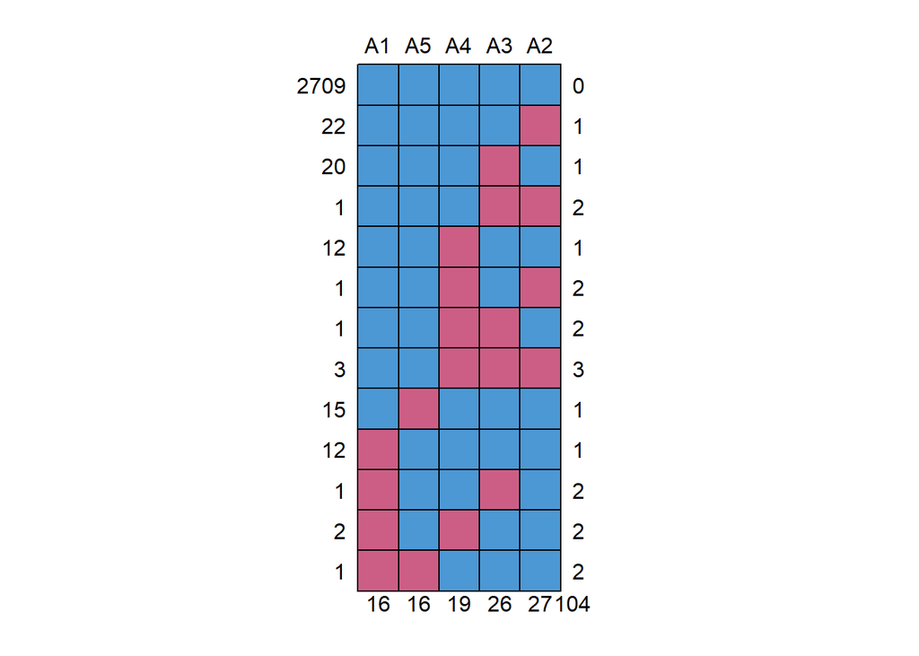

```
##      A1 A5 A4 A3 A2
## 2709  1  1  1  1  1   0
## 22    1  1  1  1  0   1
## 20    1  1  1  0  1   1
## 1     1  1  1  0  0   2
## 12    1  1  0  1  1   1
## 1     1  1  0  1  0   2
## 1     1  1  0  0  1   2
## 3     1  1  0  0  0   3
## 15    1  0  1  1  1   1
## 12    0  1  1  1  1   1
## 1     0  1  1  0  1   2
## 2     0  1  0  1  1   2
## 1     0  0  1  1  1   2
##      16 16 19 26 27 104
```

```r
bfi_a |>
  select(A1:A5) |>
mice::md.pattern()
```

##### 3.1.8.1.2 mice::md.pairs

- rr: 2つの変数が観測される
- rm: 行があり，列がmissing
- mr: 行がmissing，列があり
- mm: 2つの変数がmissing

```r
bfi_a |>
  select(A1:A5) |>
mice::md.pairs()
```

```
## $rr
##      A1   A2   A3   A4   A5
## A1 2784 2757 2759 2767 2769
## A2 2757 2773 2751 2758 2757
## A3 2759 2751 2774 2759 2758
## A4 2767 2758 2759 2781 2765
## A5 2769 2757 2758 2765 2784
##
## $rm
##    A1 A2 A3 A4 A5
## A1  0 27 25 17 15
## A2 16  0 22 15 16
## A3 15 23  0 15 16
## A4 14 23 22  0 16
## A5 15 27 26 19  0
##
## $mr
##    A1 A2 A3 A4 A5
## A1  0 16 15 14 15
## A2 27  0 23 23 27
## A3 25 22  0 22 26
## A4 17 15 15  0 19
## A5 15 16 16 16  0
##
## $mm
##    A1 A2 A3 A4 A5
## A1 16  0  1  2  1
## A2  0 27  4  4  0
## A3  1  4 26  4  0
## A4  2  4  4 19  0
## A5  1  0  0  0 16
```

##### 3.1.8.1.3 naniar

### 3.1.9 ★合計得点の作成

```r
bfi_added <-
  bfi_added |>
  mutate(agree = A1_r + A2 + A3 + A4 + A5,
         conscientious = C1 + C2 + C3 + C4_r + C5_r,
         extraversion = E1_r + E2_r + E3 + E4 + E5,
         neuroticism = N1 + N2 + N3 + N4 + N5,
         openness =  O1 + O2_r + O3 + O4 + O5_r
  )

bfi_added_cor <-
  bfi_added |>
  select(agree:openness)

cor(bfi_added_cor, use = "complete.obs") |>
  round(digits = 1)
```

```
##               agree conscientious extraversion neuroticism openness
## agree           1.0           0.3          0.5        -0.2      0.1
## conscientious   0.3           1.0          0.3        -0.2      0.2
## extraversion    0.5           0.3          1.0        -0.2      0.2
## neuroticism    -0.2          -0.2         -0.2         1.0     -0.1
## openness        0.1           0.2          0.2        -0.1      1.0
```

```r
rm(bfi_added_cor)
```

#### 3.1.9.1 合計得点の作成(関数)

```r
bfi |>
  select(starts_with("n")) |>
  names()
```

```
## [1] "N1" "N2" "N3" "N4" "N5"
```

```r
bfi_added |>
  mutate(neuroticism2 = rowSums(across(c(N1:N5)))) |>
  select(N1:N5,neuroticism, neuroticism2) |>
  head()
```

```
##       N1 N2 N3 N4 N5 neuroticism neuroticism2
## 61617  3  4  2  2  3          14           14
## 61618  3  3  3  5  5          19           19
## 61620  4  5  4  2  3          18           18
## 61621  2  5  2  4  1          14           14
## 61622  2  3  4  4  3          16           16
## 61623  3  5  2  2  3          15           15
```

##### 3.1.9.1.1 合計得点の作成(関数: base)

```r
names(bfi_a)
```

```
##  [1] "A1"        "A2"        "A3"        "A4"        "A5"        "gender"
##  [7] "education" "age"       "A1r"       "total_a"
```

```r
bfi_a <-
bfi_a %>%
  mutate(total_a2 = rowSums(.[c(2:5, 9)])) # na.rm = TRUEにするとNAは0扱いになる

# 確認
bfi_a |>
  select(A1r, A2:A5, total_a, total_a2) |>
  head()
```

```
## # A tibble: 6 × 7
##     A1r    A2    A3    A4    A5 total_a total_a2
##   <int> <int> <int> <int> <int>   <int>    <dbl>
## 1     5     4     3     4     4      20       20
## 2     5     4     5     2     5      21       21
## 3     2     4     5     4     4      19       19
## 4     3     4     6     5     5      23       23
## 5     5     3     3     4     5      20       20
## 6     1     6     5     6     5      23       23
```

### 3.1.10 文字の指定によるデータの表示

```r
bfi_a |>
  count(education) |>
  filter(str_detect(education, "college"))
```

```
## # A tibble: 2 × 2
##   education            n
##   <fct>            <int>
## 1 some college      1249
## 2 college graduate   394
```

### 3.1.11 欠損のある得点の表示

```r
bfi_a |>
  select(A1, A1r, A2:A5, total_a, total_a2) |>
  filter(is.na(total_a)) |>
  print(n = 10)
```

```
## # A tibble: 91 × 8
##       A1   A1r    A2    A3    A4    A5 total_a total_a2
##    <int> <int> <int> <int> <int> <int>   <int>    <dbl>
##  1     2     5    NA     4     6     4      NA       NA
##  2    NA    NA     4     5     6     4      NA       NA
##  3     4     3     5     4    NA     3      NA       NA
##  4     1     6     4    NA     6     6      NA       NA
##  5     1     6     5    NA     5     6      NA       NA
##  6     1     6    NA     4     6     5      NA       NA
##  7     1     6     5    NA     6     5      NA       NA
##  8     2     5    NA     5     5     2      NA       NA
##  9    NA    NA     5     4     3     4      NA       NA
## 10     2     5     4     4     6    NA      NA       NA
## # ℹ 81 more rows
```

### 3.1.12 欠損値NAを他の値に置き換え: replace_na

#### 3.1.12.1 文字型の場合

```r
# 文字型にした列を新たに作成
bfi_a <-
  bfi_a |>
  mutate(education2 = as.character(education),
         A1nm = as.character(A1),
         A2nm = as.character(A2))


bfi_anm <-
bfi_a |>
  mutate(education2 = replace_na(education2, "unknown"), # 因子型には使えない？
              A1nm = replace_na(A1nm, "不明"),           # 文字型に
              A2nm = replace_na(A2nm, "不明"))           # 文字型に

bfi_anm |> count(education2)
```

```
## # A tibble: 6 × 2
##   education2           n
##   <chr>            <int>
## 1 HS                 224
## 2 college graduate   394
## 3 finished HS        292
## 4 graduate degree    418
## 5 some college      1249
## 6 unknown            223
```

```r
bfi_anm |> count(A1nm)
```

```
## # A tibble: 7 × 2
##   A1nm      n
##   <chr> <int>
## 1 1       922
## 2 2       818
## 3 3       402
## 4 4       337
## 5 5       223
## 6 6        82
## 7 不明     16
```

#### 3.1.12.2 数値の場合

```r
test <-
  tribble(~x,
          1,
          2,
          NA)

test |>
  mutate(x2 = replace_na(x, 99))
```

```
## # A tibble: 3 × 2
##       x    x2
##   <dbl> <dbl>
## 1     1     1
## 2     2     2
## 3    NA    99
```

```r
test |>
  replace_na(list(x = 99))
```

```
## # A tibble: 3 × 1
##       x
##   <dbl>
## 1     1
## 2     2
## 3    99
```

### 3.1.13 特定の値を欠損値にする: na_if

#### 3.1.13.1 文字型の場合

```r
bfi_anm |>
  mutate(A1nmr = na_if(A1nm, "不明")) |>
  count(A1nm, A1nmr)
```

```
## # A tibble: 7 × 3
##   A1nm  A1nmr     n
##   <chr> <chr> <int>
## 1 1     1       922
## 2 2     2       818
## 3 3     3       402
## 4 4     4       337
## 5 5     5       223
## 6 6     6        82
## 7 不明  <NA>     16
```

```r
bfi_arm2 <-
bfi_anm |>
  mutate(across(c(A1nm, A2nm),
            list( \(x) na_if(x, "不明"))
               )
        )


# purrr 1.0.0より前
# bfi_arm2 <-
# bfi_anm |>
#   mutate(across(c(A1nm, A2nm),
#             list(~na_if(., "不明"))
#                )
#         )


# dplyr 0.8.3より前
# bfi_arm2 <-
# bfi_anm |>
#   mutate_at(vars(A1nm, A2nm),
#             list(~na_if(., "不明"))
#   )

bfi_arm2 |> count(A1nm)
```

```
## # A tibble: 7 × 2
##   A1nm      n
##   <chr> <int>
## 1 1       922
## 2 2       818
## 3 3       402
## 4 4       337
## 5 5       223
## 6 6        82
## 7 不明     16
```

```r
bfi_arm2 |> count(A2nm)
```

```
## # A tibble: 7 × 2
##   A2nm      n
##   <chr> <int>
## 1 1        47
## 2 2       126
## 3 3       151
## 4 4       553
## 5 5      1023
## 6 6       873
## 7 不明     27
```

#### 3.1.13.2 数値型の場合

```r
test <-
  tribble(~x,
          1,
          2,
          0,
          99)

test |>
  mutate(x2 = na_if(x, 0),
         x2 = na_if(x2, 99))
```

```
## # A tibble: 4 × 2
##       x    x2
##   <dbl> <dbl>
## 1     1     1
## 2     2     2
## 3     0    NA
## 4    99    NA
```

#### 3.1.13.3 別解

##### 3.1.13.3.1 文字型の場合

```r
bfi_anm |>
  count(A1nm)
```

```
## # A tibble: 7 × 2
##   A1nm      n
##   <chr> <int>
## 1 1       922
## 2 2       818
## 3 3       402
## 4 4       337
## 5 5       223
## 6 6        82
## 7 不明     16
```

```r
bfi_anm |>
  mutate(A1nmr = if_else(A1nm == "不明", NA_character_, A1nm)) |>
  count(A1nm, A1nmr)
```

```
## # A tibble: 7 × 3
##   A1nm  A1nmr     n
##   <chr> <chr> <int>
## 1 1     1       922
## 2 2     2       818
## 3 3     3       402
## 4 4     4       337
## 5 5     5       223
## 6 6     6        82
## 7 不明  <NA>     16
```

##### 3.1.13.3.2 数値の場合

```r
test |>
  mutate(x2 = if_else(x %in% c(0, 99), NA_real_, x))
```

```
## # A tibble: 4 × 2
##       x    x2
##   <dbl> <dbl>
## 1     1     1
## 2     2     2
## 3     0    NA
## 4    99    NA
```

```r
test |>
  mutate(x2 = if_else(x == 0 | x == 99, NA_real_, x))
```

```
## # A tibble: 4 × 2
##       x    x2
##   <dbl> <dbl>
## 1     1     1
## 2     2     2
## 3     0    NA
## 4    99    NA
```

## 3.2 年齢層変数作成

```r
bfi_a <-
bfi_a |>
  mutate(agec = case_when(
          age < 20              ~ "20歳未満",
          age >= 20  & age < 30 ~ "30歳未満",
          age >= 30  & age < 40 ~ "40歳未満",
          age >= 40  & age < 50 ~ "50歳未満",
          age >= 50  & age < 60 ~ "60歳未満",
          age >= 60             ~ "60歳以上"
  ))

bfi_a |>
  count(age, agec)
```

```
## # A tibble: 64 × 3
##      age agec         n
##    <int> <chr>    <int>
##  1     3 20歳未満     1
##  2     9 20歳未満     1
##  3    11 20歳未満     3
##  4    12 20歳未満    28
##  5    13 20歳未満     7
##  6    14 20歳未満    21
##  7    15 20歳未満    26
##  8    16 20歳未満    61
##  9    17 20歳未満   100
## 10    18 20歳未満   124
## # ℹ 54 more rows
```

### 3.2.1 年齢層変数作成（欠損値がある場合）

```r
# 特定範囲の値を欠損値に
bfi_am <-
  bfi_a |>
  mutate(age = case_when(
            age <  10 ~ NA_integer_, # 10歳未満はNA，整数の場合はこれ
            age >= 70 ~ NA_integer_, # 70歳はNA
            TRUE      ~ age)         # その他はageそのまま
         )

bfi_am <-
bfi_am |>
  mutate(agec = case_when(
          age <  20             ~ "20歳未満",
          age >= 20  & age < 30 ~ "30歳未満",
          age >= 30  & age < 40 ~ "40歳未満",
          age >= 40  & age < 50 ~ "50歳未満",
          age >= 50  & age < 60 ~ "60歳未満",
          age >= 60             ~ "60歳以上",
          is.na(age)            ~ "年齢不明"
  ))

bfi_am |>
  count(age, agec)
```

```
## # A tibble: 59 × 3
##      age agec         n
##    <int> <chr>    <int>
##  1    11 20歳未満     3
##  2    12 20歳未満    28
##  3    13 20歳未満     7
##  4    14 20歳未満    21
##  5    15 20歳未満    26
##  6    16 20歳未満    61
##  7    17 20歳未満   100
##  8    18 20歳未満   124
##  9    19 20歳未満   190
## 10    20 30歳未満   212
## # ℹ 49 more rows
```

### 3.2.2 年齢層変数作成(cut_intervalで自動的に)

```r
# カテゴリの各区間の長さが等しくなるように
bfi_a |>
  mutate(agec2 = cut_interval(age, 5)) |> # 分割の数
  count(agec2)
```

```
## # A tibble: 5 × 2
##   agec2           n
##   <fct>       <int>
## 1 [3,19.6]      562
## 2 (19.6,36.2]  1602
## 3 (36.2,52.8]   522
## 4 (52.8,69.4]   110
## 5 (69.4,86]       4
```

```r
# カテゴリの各区間の人数が等しくなるように
bfi_a |>
  mutate(agec2 = cut_number(age, 5)) |> # 分割の数
  count(agec2)
```

```
## # A tibble: 5 × 2
##   agec2       n
##   <fct>   <int>
## 1 [3,19]    562
## 2 (19,23]   616
## 3 (23,29]   578
## 4 (29,38]   496
## 5 (38,86]   548
```

```r
# カテゴリの各区間の長さを指定
bfi_a |>
  mutate(agec2 = cut_width(age, width = 20, center = 10)) |>
                     # width = 区間の長さ, デフォルトだとcenter = 0になってしまうので10に
  count(agec2)
```

```
## # A tibble: 5 × 2
##   agec2        n
##   <fct>    <int>
## 1 [0,20]     774
## 2 (20,40]   1584
## 3 (40,60]    420
## 4 (60,80]     21
## 5 (80,100]     1
```

## 3.3 データの連結

### 3.3.1 idの作成

```r
bfi_a <-
bfi_a |>
  mutate(id = row_number())

bfi_a <-
bfi_a |> select(id, everything())

bfi_a
```

```
## # A tibble: 2,800 × 16
##       id    A1    A2    A3    A4    A5 gender education      age   A1r total_a
##    <int> <int> <int> <int> <int> <int> <fct>  <fct>        <int> <int>   <int>
##  1     1     2     4     3     4     4 male   <NA>            16     5      20
##  2     2     2     4     5     2     5 female <NA>            18     5      21
##  3     3     5     4     5     4     4 female <NA>            17     2      19
##  4     4     4     4     6     5     5 female <NA>            17     3      23
##  5     5     2     3     3     4     5 male   <NA>            17     5      20
##  6     6     6     6     5     6     5 female some college    21     1      23
##  7     7     2     5     5     3     5 male   <NA>            18     5      23
##  8     8     4     3     1     5     1 male   finished HS     19     3      13
##  9     9     4     3     6     3     3 male   HS              19     3      18
## 10    10     2     5     6     6     5 female <NA>            17     5      27
## # ℹ 2,790 more rows
## # ℹ 5 more variables: total_a2 <dbl>, education2 <chr>, A1nm <chr>, A2nm <chr>,
## #   agec <chr>
```

### 3.3.2 左側のdfに合わせる：left_join

```r
# A1
bfi_a_20_30 <-
bfi_a |>
  slice(c(20:30)) |>
  select(id, education, A1)

bfi_a_20_30
```

```
## # A tibble: 11 × 3
##       id education          A1
##    <int> <fct>           <int>
##  1    20 <NA>                4
##  2    21 <NA>                5
##  3    22 <NA>                1
##  4    23 graduate degree     1
##  5    24 finished HS         2
##  6    25 HS                  4
##  7    26 some college        1
##  8    27 graduate degree     2
##  9    28 <NA>                2
## 10    29 some college        2
## 11    30 some college        4
```

```r
# genderとage
bfi_a_20_25 <-
bfi_a |>
  slice(20:25) |>
  select(id, education, gender, age)

bfi_a_20_25
```

```
## # A tibble: 6 × 4
##      id education       gender   age
##   <int> <fct>           <fct>  <int>
## 1    20 <NA>            female    17
## 2    21 <NA>            male      17
## 3    22 <NA>            female    17
## 4    23 graduate degree male      68
## 5    24 finished HS     female    27
## 6    25 HS              male      18
```

```r
left_join(bfi_a_20_30, bfi_a_20_25, by = c("id", "education"))
```

```
## # A tibble: 11 × 5
##       id education          A1 gender   age
##    <int> <fct>           <int> <fct>  <int>
##  1    20 <NA>                4 female    17
##  2    21 <NA>                5 male      17
##  3    22 <NA>                1 female    17
##  4    23 graduate degree     1 male      68
##  5    24 finished HS         2 female    27
##  6    25 HS                  4 male      18
##  7    26 some college        1 <NA>      NA
##  8    27 graduate degree     2 <NA>      NA
##  9    28 <NA>                2 <NA>      NA
## 10    29 some college        2 <NA>      NA
## 11    30 some college        4 <NA>      NA
```

### 3.3.3 一致したケースのみ残す: inner_join

```r
inner_join(bfi_a_20_30, bfi_a_20_25, by = c("id", "education"))
```

```
## # A tibble: 6 × 5
##      id education          A1 gender   age
##   <int> <fct>           <int> <fct>  <int>
## 1    20 <NA>                4 female    17
## 2    21 <NA>                5 male      17
## 3    22 <NA>                1 female    17
## 4    23 graduate degree     1 male      68
## 5    24 finished HS         2 female    27
## 6    25 HS                  4 male      18
```

```r
# inner_join(bfi_a_20_30, bfi_a_20_25, by = c("id"))
```

### 3.3.4 一致したケースのみ残して連結先の変数は連結せず: semi_join

```r
semi_join(bfi_a_20_30, bfi_a_20_25, by = c("id", "education"))
```

```
## # A tibble: 6 × 3
##      id education          A1
##   <int> <fct>           <int>
## 1    20 <NA>                4
## 2    21 <NA>                5
## 3    22 <NA>                1
## 4    23 graduate degree     1
## 5    24 finished HS         2
## 6    25 HS                  4
```

### 3.3.5 連結元データを一致したケース以外に

```r
anti_join(bfi_a_20_30, bfi_a_20_25, by = c("id", "education"))
```

```
## # A tibble: 5 × 3
##      id education          A1
##   <int> <fct>           <int>
## 1    26 some college        1
## 2    27 graduate degree     2
## 3    28 <NA>                2
## 4    29 some college        2
## 5    30 some college        4
```

## 3.4 変数のrename

### 3.4.1 2018年データと2019年データを作成

- 面倒なのでデータの中身は同じものとする。yearだけ違う

```r
bfi_a_2018 <-
bfi_a |>
  slice(1:5) |> #小さくするため最初の5名のみ
  select(id, A1:A3, gender) |>
  mutate(year = 2018)

bfi_a_2019 <-
bfi_a |>
  slice(1:5) |>
  select(id, A1:A3, gender) |>
  mutate(year = 2019)

bfi_a_2018
```

```
## # A tibble: 5 × 6
##      id    A1    A2    A3 gender  year
##   <int> <int> <int> <int> <fct>  <dbl>
## 1     1     2     4     3 male    2018
## 2     2     2     4     5 female  2018
## 3     3     5     4     5 female  2018
## 4     4     4     4     6 female  2018
## 5     5     2     3     3 male    2018
```

```r
bfi_a_2019
```

```
## # A tibble: 5 × 6
##      id    A1    A2    A3 gender  year
##   <int> <int> <int> <int> <fct>  <dbl>
## 1     1     2     4     3 male    2019
## 2     2     2     4     5 female  2019
## 3     3     5     4     5 female  2019
## 4     4     4     4     6 female  2019
## 5     5     2     3     3 male    2019
```

### 3.4.2 年ごとのデータフレームにそれぞれの年の値を追加して横に連結

- 数が少なければ手動でできるが，多いと大変

```r
bfi_a_2018w <-
  bfi_a_2018 |>
  rename_with(\(x) str_c(x, "_18"),
              !c(id, gender, year)) |>
  select(-year)

bfi_a_2019w <-
  bfi_a_2019 |>
  rename_with(\(x) str_c(x, "_19"),
              !c(id, gender))

# dplyr 0.8.3以前
# bfi_a_2018w <-
#   bfi_a_2018 |>
#   rename_at(vars(-id, -gender, -year),
#             list(~str_c(., "_18"))) |>
#   select(-year)
#
# bfi_a_2019w <-
#   bfi_a_2019 |>
#   rename_at(vars(-id, -gender),
#             list(~str_c(., "_19")))

bfi_a_all <-
  full_join(bfi_a_2018w, bfi_a_2019w) |>
  select(id, gender,  everything())

bfi_a_all
```

```
## # A tibble: 5 × 9
##      id gender A1_18 A2_18 A3_18 A1_19 A2_19 A3_19 year_19
##   <int> <fct>  <int> <int> <int> <int> <int> <int>   <dbl>
## 1     1 male       2     4     3     2     4     3    2019
## 2     2 female     2     4     5     2     4     5    2019
## 3     3 female     5     4     5     5     4     5    2019
## 4     4 female     4     4     6     4     4     6    2019
## 5     5 male       2     3     3     2     3     3    2019
```

### 3.4.3 個々のデータフレームをlistにまとめて自動で変数名変換

- https://stackoverflow.com/questions/61914847/replacing-dplyrfuns-within-imap-that-refers-to-the-y-value

```r
# リスト作成
bfi_a_list <- list(bfi_a_2018, bfi_a_2019)
names(bfi_a_list)
```

[output not shown]

```r
# リストの各要素に名前
bfi_a_list <-
set_names(bfi_a_list, c("2018", "2019"))
names(bfi_a_list)
```

```
## [1] "2018" "2019"
```

```r
# リストの要素名をそれぞれのdfの変数の接尾辞に

imap(bfi_a_list,
     \(a,b){
       rename_with(a,
                   \(x){str_c(x, b, sep = "_")}, !id)}
)
```

```
## $`2018`
## # A tibble: 5 × 6
##      id A1_2018 A2_2018 A3_2018 gender_2018 year_2018
##   <int>   <int>   <int>   <int> <fct>           <dbl>
## 1     1       2       4       3 male             2018
## 2     2       2       4       5 female           2018
## 3     3       5       4       5 female           2018
## 4     4       4       4       6 female           2018
## 5     5       2       3       3 male             2018
##
## $`2019`
## # A tibble: 5 × 6
##      id A1_2019 A2_2019 A3_2019 gender_2019 year_2019
##   <int>   <int>   <int>   <int> <fct>           <dbl>
## 1     1       2       4       3 male             2019
## 2     2       2       4       5 female           2019
## 3     3       5       4       5 female           2019
## 4     4       4       4       6 female           2019
## 5     5       2       3       3 male             2019
```

```r
# purrr 1.0.0より前
# bfi_a_list <-
#  imap(bfi_a_list,
#        function(a,b){
#          rename_with(a,
#          ~{str_c(., b, sep = "_")}, !id)}
#       )

bfi_a_list |> head()
```

```
## $`2018`
## # A tibble: 5 × 6
##      id    A1    A2    A3 gender  year
##   <int> <int> <int> <int> <fct>  <dbl>
## 1     1     2     4     3 male    2018
## 2     2     2     4     5 female  2018
## 3     3     5     4     5 female  2018
## 4     4     4     4     6 female  2018
## 5     5     2     3     3 male    2018
##
## $`2019`
## # A tibble: 5 × 6
##      id    A1    A2    A3 gender  year
##   <int> <int> <int> <int> <fct>  <dbl>
## 1     1     2     4     3 male    2019
## 2     2     2     4     5 female  2019
## 3     3     5     4     5 female  2019
## 4     4     4     4     6 female  2019
## 5     5     2     3     3 male    2019
```

```r
# リスト内のデータフレームを横に連結
bfi_a_all_wide <-
  bfi_a_list |>
  reduce(full_join, by = "id")



bfi_a_all_wide
```

```
## # A tibble: 5 × 11
##      id  A1.x  A2.x  A3.x gender.x year.x  A1.y  A2.y  A3.y gender.y year.y
##   <int> <int> <int> <int> <fct>     <dbl> <int> <int> <int> <fct>     <dbl>
## 1     1     2     4     3 male       2018     2     4     3 male       2019
## 2     2     2     4     5 female     2018     2     4     5 female     2019
## 3     3     5     4     5 female     2018     5     4     5 female     2019
## 4     4     4     4     6 female     2018     4     4     6 female     2019
## 5     5     2     3     3 male       2018     2     3     3 male       2019
```

```r
# old
# bfi_a_list <-
# set_names(bfi_a_list, c("bfi_a_2018", "bfi_a_2019"))
#
# # もう1つの方法
# # names(bfi_a_list) <- c("bfi_a_2018", "bfi_a_2019")
#
# names(bfi_a_list)



# リストの各要素を変数名の接尾辞に
# for (i in names(bfi_a_list)){
#   colnames(bfi_a_list[[i]]) <- c("id",
#                                str_c("A1", "_", i),
#                                str_c("A2", "_", i),
#                                str_c("A3", "_", i),
#                                "gender", "year"
#                                 )
# }
#
# # リスト内のデータフレームを横に連結
# bfi_a_all_wide <-
#   bfi_a_list |>
#   reduce(full_join, by = c("id", "gender"))
#
# # 変数名からbfi_aを取る
# bfi_a_all_wide <-
#   bfi_a_all_wide |>
#   select(-starts_with("year")) |>
#   rename_with(~str_replace(., "bfi_a_", ""),
#               matches("bfi_a"))


# dplyr 0.8.3以前
# bfi_a_all_wide <-
#   bfi_a_all_wide |>
#   select(-starts_with("year")) |>
#   rename_at(vars(matches("bfi_a")),
#             list(~str_replace(., "bfi_a_", "")))
```

## 3.5 リストの深い階層から値を取り出す（α係数を例に）

### 3.5.1 データフレームのリスト作成

```r
bfi_la <- bfi |> select(A2:A4)
bfi_lc <- bfi |> select(C1:C3)

bfi_list <- list(bfi_la, bfi_lc)
```

### 3.5.2 各データフレームの信頼性算出

```r
bfi_alpha <-
  map(bfi_list, alpha)

bfi_alpha |>
  str(list.len = 3) # 各要素の最初の3つのみ表示
```

```
## List of 2
##  $ :List of 15
##   ..$ total        :'data.frame':    1 obs. of  9 variables:
##   .. ..$ raw_alpha: num 0.652
##   .. ..$ std.alpha: num 0.661
##   .. ..$ G6(smc)  : num 0.573
##   .. .. [list output truncated]
##   ..$ alpha.drop   :'data.frame':    3 obs. of  8 variables:
##   .. ..$ raw_alpha: num [1:3] 0.528 0.493 0.652
##   .. ..$ std.alpha: num [1:3] 0.531 0.503 0.654
##   .. ..$ G6(smc)  : num [1:3] 0.361 0.336 0.486
##   .. .. [list output truncated]
##   ..$ item.stats   :'data.frame':    3 obs. of  7 variables:
##   .. ..$ n     : num [1:3] 2773 2774 2781
##   .. ..$ raw.r : num [1:3] 0.755 0.789 0.769
##   .. ..$ std.r : num [1:3] 0.786 0.798 0.733
##   .. .. [list output truncated]
##   .. [list output truncated]
##   ..- attr(*, "class")= chr [1:2] "psych" "alpha"
##  $ :List of 15
##   ..$ total        :'data.frame':    1 obs. of  9 variables:
##   .. ..$ raw_alpha: num 0.631
##   .. ..$ std.alpha: num 0.631
##   .. ..$ G6(smc)  : num 0.538
##   .. .. [list output truncated]
##   ..$ alpha.drop   :'data.frame':    3 obs. of  8 variables:
##   .. ..$ raw_alpha: num [1:3] 0.524 0.47 0.598
##   .. ..$ std.alpha: num [1:3] 0.524 0.47 0.599
##   .. ..$ G6(smc)  : num [1:3] 0.355 0.307 0.428
##   .. .. [list output truncated]
##   ..$ item.stats   :'data.frame':    3 obs. of  7 variables:
##   .. ..$ n     : num [1:3] 2779 2776 2780
##   .. ..$ raw.r : num [1:3] 0.755 0.79 0.734
##   .. ..$ std.r : num [1:3] 0.762 0.783 0.73
##   .. .. [list output truncated]
##   .. [list output truncated]
##   ..- attr(*, "class")= chr [1:2] "psych" "alpha"
```

### 3.5.3 各データフレーム要素から”total”要素を取り出す

```r
alpha_total <-
  map(bfi_alpha, "total")

alpha_total
```

```
## [[1]]
##  raw_alpha std.alpha   G6(smc) average_r      S/N       ase     mean      sd
##  0.6517571 0.6614361 0.5733395 0.3943862 1.953652 0.0114212 4.705101 1.01632
##   median_r
##  0.3613966
##
## [[2]]
##  raw_alpha std.alpha   G6(smc) average_r      S/N        ase     mean       sd
##  0.6313163 0.6313295 0.5375642 0.3633883 1.712449 0.01206293 4.392202 0.977292
##   median_r
##  0.3553767
```

### 3.5.4 α係数のみに

```r
map_dbl(alpha_total, "raw_alpha")
```

```
## [1] 0.6517571 0.6313163
```

# 4 データフレームの表示

```r
bfi_s <-
 bfi |>
 slice(1:15) |>
 select(A1:A5, gender, education, age)
```

## 4.1 kable

```r
kable(bfi_s)
```

| A1 | A2 | A3 | A4 | A5 | gender | education | age |
| --- | --- | --- | --- | --- | --- | --- | --- |
| 2 | 4 | 3 | 4 | 4 | 1 | NA | 16 |
| 2 | 4 | 5 | 2 | 5 | 2 | NA | 18 |
| 5 | 4 | 5 | 4 | 4 | 2 | NA | 17 |
| 4 | 4 | 6 | 5 | 5 | 2 | NA | 17 |
| 2 | 3 | 3 | 4 | 5 | 1 | NA | 17 |
| 6 | 6 | 5 | 6 | 5 | 2 | 3 | 21 |
| 2 | 5 | 5 | 3 | 5 | 1 | NA | 18 |
| 4 | 3 | 1 | 5 | 1 | 1 | 2 | 19 |
| 4 | 3 | 6 | 3 | 3 | 1 | 1 | 19 |
| 2 | 5 | 6 | 6 | 5 | 2 | NA | 17 |
| 4 | 4 | 5 | 6 | 5 | 1 | 1 | 21 |
| 2 | 5 | 5 | 5 | 5 | 1 | NA | 16 |
| 5 | 5 | 5 | 6 | 4 | 2 | NA | 16 |
| 5 | 5 | 5 | 6 | 6 | 1 | NA | 16 |
| 4 | 5 | 2 | 2 | 1 | 1 | 1 | 17 |

## 4.2 formattable::formattable

```r
formattable::formattable(bfi_s)
```

| A1 | A2 | A3 | A4 | A5 | gender | education | age |
| --- | --- | --- | --- | --- | --- | --- | --- |
| 2 | 4 | 3 | 4 | 4 | 1 | NA | 16 |
| 2 | 4 | 5 | 2 | 5 | 2 | NA | 18 |
| 5 | 4 | 5 | 4 | 4 | 2 | NA | 17 |
| 4 | 4 | 6 | 5 | 5 | 2 | NA | 17 |
| 2 | 3 | 3 | 4 | 5 | 1 | NA | 17 |
| 6 | 6 | 5 | 6 | 5 | 2 | 3 | 21 |
| 2 | 5 | 5 | 3 | 5 | 1 | NA | 18 |
| 4 | 3 | 1 | 5 | 1 | 1 | 2 | 19 |
| 4 | 3 | 6 | 3 | 3 | 1 | 1 | 19 |
| 2 | 5 | 6 | 6 | 5 | 2 | NA | 17 |
| 4 | 4 | 5 | 6 | 5 | 1 | 1 | 21 |
| 2 | 5 | 5 | 5 | 5 | 1 | NA | 16 |
| 5 | 5 | 5 | 6 | 4 | 2 | NA | 16 |
| 5 | 5 | 5 | 6 | 6 | 1 | NA | 16 |
| 4 | 5 | 2 | 2 | 1 | 1 | 1 | 17 |

## 4.3 DT::datatable

```r
DT::datatable(bfi_s)
```

|  | A1 | A2 | A3 | A4 | A5 | gender | education | age |
| --- | --- | --- | --- | --- | --- | --- | --- | --- |
| 1 | 2 | 4 | 3 | 4 | 4 | 1 |  | 16 |
| 2 | 2 | 4 | 5 | 2 | 5 | 2 |  | 18 |
| 3 | 5 | 4 | 5 | 4 | 4 | 2 |  | 17 |
| 4 | 4 | 4 | 6 | 5 | 5 | 2 |  | 17 |
| 5 | 2 | 3 | 3 | 4 | 5 | 1 |  | 17 |
| 6 | 6 | 6 | 5 | 6 | 5 | 2 | 3 | 21 |
| 7 | 2 | 5 | 5 | 3 | 5 | 1 |  | 18 |
| 8 | 4 | 3 | 1 | 5 | 1 | 1 | 2 | 19 |
| 9 | 4 | 3 | 6 | 3 | 3 | 1 | 1 | 19 |
| 10 | 2 | 5 | 6 | 6 | 5 | 2 |  | 17 |

[output cut: 5 more lines]

# 5 基本統計量等を一気に確認

## 5.1 summarytools::dfSummary

- うまく表示されないので出力なし

## 5.2 table1パッケージ

```r
table1::table1(~ A1 + A2 + A3 + age + education | gender, data = bfi_a)
```

|  | male (N=919) | female (N=1881) | Overall (N=2800) |
| --- | --- | --- | --- |
| A1 |  |  |  |
| Mean (SD) | 2.73 (1.43) | 2.26 (1.37) | 2.41 (1.41) |
| Median [Min, Max] | 2.00 [1.00, 6.00] | 2.00 [1.00, 6.00] | 2.00 [1.00, 6.00] |
| Missing | 1 (0.1%) | 15 (0.8%) | 16 (0.6%) |
| A2 |  |  |  |
| Mean (SD) | 4.50 (1.26) | 4.95 (1.09) | 4.80 (1.17) |
| Median [Min, Max] | 5.00 [1.00, 6.00] | 5.00 [1.00, 6.00] | 5.00 [1.00, 6.00] |
| Missing | 11 (1.2%) | 16 (0.9%) | 27 (1.0%) |
| A3 |  |  |  |
| Mean (SD) | 4.34 (1.33) | 4.73 (1.27) | 4.60 (1.30) |
| Median [Min, Max] | 5.00 [1.00, 6.00] | 5.00 [1.00, 6.00] | 5.00 [1.00, 6.00] |
| Missing | 7 (0.8%) | 19 (1.0%) | 26 (0.9%) |
| age |  |  |  |
| Mean (SD) | 28.0 (11.0) | 29.2 (11.2) | 28.8 (11.1) |
| Median [Min, Max] | 25.0 [3.00, 74.0] | 26.0 [9.00, 86.0] | 26.0 [3.00, 86.0] |
| education |  |  |  |
| HS | 93 (10.1%) | 131 (7.0%) | 224 (8.0%) |
| finished HS | 103 (11.2%) | 189 (10.0%) | 292 (10.4%) |
| some college | 356 (38.7%) | 893 (47.5%) | 1249 (44.6%) |
| college graduate | 134 (14.6%) | 260 (13.8%) | 394 (14.1%) |
| graduate degree | 152 (16.5%) | 266 (14.1%) | 418 (14.9%) |
| Missing | 81 (8.8%) | 142 (7.5%) | 223 (8.0%) |

# 6 平均値の算出

## 6.1 変数個別

### 6.1.1 summarise

```r
bfi |>
  summarise(A1 = mean(A1, na.rm = TRUE),
            A2 = mean(A2, na.rm = TRUE))
```

```
##         A1      A2
## 1 2.413434 4.80238
```

### 6.1.2 複数変数を対象

```r
bfi |>
  summarise(across(c(A1, A2),
               mean, na.rm = TRUE)
  )
```

```
##         A1      A2
## 1 2.413434 4.80238
```

```r
# dplyr 0.8.3以前
# bfi |>
#   summarise_at(vars(A1, A2),
#                mean, na.rm = TRUE)
```

### 6.1.3 関数も個別に(1)

```r
bfi |>
  summarise(across(c(A1, A2),
               list(mean, sd),
               na.rm = TRUE)
  )
```

```
##       A1_1     A1_2    A2_1    A2_2
## 1 2.413434 1.407737 4.80238 1.17202
```

```r
# dplyr 0.8.3以前
# bfi |>
#   summarise_at(vars(A1, A2),
#                list(mean, sd),
#                na.rm = TRUE)


# こちらでもOK
# bfi |>
#   summarise_at(vars(A1, A2),funs(mean(., na.rm = TRUE),
#                                     sd(., na.rm = TRUE)
#                                   )
#   )
```

### 6.1.4 関数も個別に(2)

- ※現在は動かないので要修正
- nはリストワイズ

### 6.1.5 関数も個別に(3)

- nはペアワイズ

```r
bfi |>
  summarise(across(c(A1, A2),
               list(mean = \(x) mean(x, na.rm = TRUE),
                      sd = \(x) sd(x, na.rm = TRUE),
                       n = \(x) sum(!is.na(x)))    # 欠損のない行の合計
                  )
               )
```

```
##    A1_mean    A1_sd A1_n A2_mean   A2_sd A2_n
## 1 2.413434 1.407737 2784 4.80238 1.17202 2773
```

```r
# purrr 1.0.0より前
# bfi |>
#   summarise(across(c(A1, A2),
#                list(mean = ~mean(., na.rm = TRUE),
#                       sd = ~sd(., na.rm = TRUE),
#                        n = ~sum(!is.na(.)))    # 欠損のない行の合計
#                   )
#                )

# dplyr 0.8.3以前
# bfi |>
#   summarise_at(vars(A1, A2),
#                list(~mean(., na.rm = TRUE),
#                     ~sd(., na.rm = TRUE),
#                 n = ~sum(!is.na(.))    # 欠損のない行の合計
#                     )
#                )

# bfi |>
#   summarise_at(vars(A1, A2),
#                funs(mean(., na.rm = TRUE),
#                     sd(., na.rm = TRUE),
#                     n = sum(!is.na(.))    # 欠損のない行の合計
#                     )
#                )
```

### 6.1.6 選択した変数すべて

```r
bfi |>
  select(A1:A5) |>
  summarise(across(everything(),
            mean, na.rm = TRUE) # , .names = "{col}_mean"
  )
```

```
##         A1      A2       A3       A4       A5
## 1 2.413434 4.80238 4.603821 4.699748 4.560345
```

```r
# dplyr 0.8.3以前
# bfi |>
#   select(A1:A5) |>
#   summarise_all(mean, na.rm = TRUE)
```

## 6.2 層別

```r
bfi |>
  select(A1:A5, gender) |>
  group_by(gender) |>
  summarise(across(everything(),
    mean, na.rm = TRUE)
  )
```

```
## # A tibble: 2 × 6
##   gender    A1    A2    A3    A4    A5
##    <int> <dbl> <dbl> <dbl> <dbl> <dbl>
## 1      1  2.73  4.50  4.34  4.43  4.38
## 2      2  2.26  4.95  4.73  4.83  4.65
```

```r
# dplyr 0.8.3以前
# bfi |>
#   select(A1:A5, gender) |>
#   group_by(gender) |>
#   summarise_all(mean, na.rm = TRUE)
```

### 6.2.1 層別および全体の値を一度に算出

```r
bfi_a |> # 性別の結果
  group_by(gender) |>
  summarise(across(c(A1, A2),
               list(\(x) mean(x, na.rm = TRUE),
                    \(x) sd(x, na.rm = TRUE),
                 n = \(x) sum(!is.na(x)))
                    )
               ) %>% # native pipeが動かないため
  bind_rows(.,         # 上で作ったデータフレームがここに
            bfi_a |>  # 全体の結果
                summarise(across(c(A1, A2),
               list(\(x) mean(x, na.rm = TRUE),
                    \(x) sd(x, na.rm = TRUE),
                 n = \(x) sum(!is.na(x)))
                                 )
                             ) |>
              mutate(gender = "all") # 最初に作ったデータフレームにgenderの列があるため
            )
```

```
## # A tibble: 3 × 7
##   gender  A1_1  A1_2  A1_n  A2_1  A2_2  A2_n
##   <chr>  <dbl> <dbl> <int> <dbl> <dbl> <int>
## 1 male    2.73  1.43   918  4.50  1.26   908
## 2 female  2.26  1.37  1866  4.95  1.09  1865
## 3 all     2.41  1.41  2784  4.80  1.17  2773
```

```r
# dplyr 0.8.3以前
# bfi_a |> # 性別の結果
#   group_by(gender) |>
#   summarise_at(vars(A1, A2),
#                list(~mean(., na.rm = TRUE),
#                       ~sd(., na.rm = TRUE),
#                  n = ~sum(!is.na(.))
#                     )
#                ) |>
#   bind_rows(.,         # 上で作ったデータフレームがここに
#             bfi_a |>  # 全体の結果
#                 summarise_at(vars(A1, A2),
#                              list(~mean(., na.rm = TRUE),
#                                     ~sd(., na.rm = TRUE),
#                                n = ~sum(!is.na(.))
#                                  )
#                              ) |>
#               mutate(gender = "all") # 最初に作ったデータフレームにgenderの列があるため
#             )
```

### 6.2.2 要約統計量を表示させたい形式に整形する

#### 6.2.2.1 平均値と標準偏差を列に

```r
bfi |>
summarise(across(c(A1, A2),
             list(mean = \(x) mean(x, na.rm = TRUE),
                  sd   = \(x) sd(x, na.rm = TRUE))
                )
             ) |>
  pivot_longer(everything(),
               names_to = c("items", ".value"), # ".value"の部分を列名に
               names_pattern = "(.*)_(.*)") 　  # 正規表現
```

```
## # A tibble: 2 × 3
##   items  mean    sd
##   <chr> <dbl> <dbl>
## 1 A1     2.41  1.41
## 2 A2     4.80  1.17
```

```r
## 強引に縦にしてから横に
# bfi |>
# summarise(across(c(A1, A2),
#              list(mean = ~mean(., na.rm = TRUE),
#                   sd   = ~sd(., na.rm = TRUE))
#                 )
#              ) |>
#   pivot_longer(everything()) |>
#   separate(name, into = c("var_name", "summarised"), sep = "_") |>
#   pivot_wider(names_from = "summarised",
#               values_from = "value")

## gather()の場合
# bfi |>
# summarise_at(vars(A1, A2),
#              list(mean, sd),
#              na.rm = TRUE) |>
#   gather() |>
#   separate(key, into = c("var_name", "summarised"), sep = "_") |>
#   spread(summarised, value)
```

#### 6.2.2.2 平均値と標準偏差を行に

```r
bfi |>
summarise(across(c(A1, A2),
             list(mean = \(x) mean(x, na.rm = TRUE),
                  sd   = \(x) sd(x, na.rm = TRUE))
                )
             ) |>
  pivot_longer(everything(),
               names_to = c(".value", "stats"),
               names_pattern = "(.*)_(.*)")
```

```
## # A tibble: 2 × 3
##   stats    A1    A2
##   <chr> <dbl> <dbl>
## 1 mean   2.41  4.80
## 2 sd     1.41  1.17
```

```r
## 別々にデータフレームを作って統合
# bfi_m <-
# bfi |>
# summarise(across(c(A1, A2),
#              mean, na.rm = TRUE)
# )
#
# bfi_sd <-
# bfi |> summarise(across(c(A1, A2),
#                      sd, na.rm = TRUE)
# )
#
# bind_rows(bfi_m, bfi_sd) |>
#   mutate(name = c("mean", "sd")) |>
#   select(name, everything())

# 次の方法でもnameを作れる
# add_column(name = c("mean", "sd"), .before = "A2")
```

# 7 頻度の確認

## 7.1 1つの項目の頻度を複数層別で確認するためにデータ構造変換

- nestした列の名前を指定
- unnestでcols = をつける

```r
res_one_var_multi_strat <-
  bfi |>
  nest(data = !c(gender, education)) |>
  mutate(freq =
           map(data, \(x) tabyl(x, A1))) |>
  select(!data) |>
  unnest(cols = c(freq)) |>
  drop_na(education) |>
  as_tibble() |>
  arrange(gender, education)


res_one_var_multi_strat |>
  head(12)
```

```
## # A tibble: 12 × 6
##    gender education    A1     n percent valid_percent
##     <int>     <int> <int> <int>   <dbl>         <dbl>
##  1      1         1     1    17  0.183        NA
##  2      1         1     2    24  0.258        NA
##  3      1         1     3    21  0.226        NA
##  4      1         1     4    15  0.161        NA
##  5      1         1     5     9  0.0968       NA
##  6      1         1     6     7  0.0753       NA
##  7      1         2     1    22  0.214         0.216
##  8      1         2     2    33  0.320         0.324
##  9      1         2     3    10  0.0971        0.0980
## 10      1         2     4    23  0.223         0.225
## 11      1         2     5    11  0.107         0.108
## 12      1         2     6     3  0.0291        0.0294
```

## 7.2 複数の項目の頻度を複数層別で確認するためにデータ構造変換

- ただし行数が非常に多くなるので大量データには不向き

```r
bfi_l <-
  bfi |>
  as_tibble() |>                    # tibble形式に変換
  select(gender,education,A1,A2) |> # 変数を選択
  drop_na() |>                      # 欠損は削除
  pivot_longer(A1:A2,            # longにする変数A1:A2を指定
         names_to = "variables",
         values_to = "score")    # key = に変数名を識別する変数、value = に変数の中身を入れる


# bfi_l <-
#   bfi |>
#   as_tibble() |>                    # tibble形式に変換
#   select(gender,education,A1,A2) |> # 変数を選択
#   drop_na() |>                      # 欠損は削除
#   gather(A1:A2,            # longにする変数A1:A2を指定
#          key = variables,
#          value = score)    # key = に変数名を識別する変数、value = に変数の中身を入れる

bfi_l |> head()
```

```
## # A tibble: 6 × 4
##   gender education variables score
##    <int>     <int> <chr>     <int>
## 1      2         3 A1            6
## 2      2         3 A2            6
## 3      1         2 A1            4
## 4      1         2 A2            3
## 5      1         1 A1            4
## 6      1         1 A2            3
```

### 7.2.1 確認

- 人数が倍になってることを確認

```r
bfi_l |>
  count(variables)
```

```
## # A tibble: 2 × 2
##   variables     n
##   <chr>     <int>
## 1 A1         2538
## 2 A2         2538
```

### 7.2.2 nestする

```r
bfi_l_nest <-
  bfi_l |>
  nest(data = score) # 層別にする変数を指定; -c(gender,education,variables)

# データ確認
bfi_l_nest |>
  arrange(variables,gender,education)
```

```
## # A tibble: 20 × 4
##    gender education variables data
##     <int>     <int> <chr>     <list>
##  1      1         1 A1        <tibble [92 × 1]>
##  2      1         2 A1        <tibble [100 × 1]>
##  3      1         3 A1        <tibble [350 × 1]>
##  4      1         4 A1        <tibble [134 × 1]>
##  5      1         5 A1        <tibble [151 × 1]>
##  6      2         1 A1        <tibble [129 × 1]>
##  7      2         2 A1        <tibble [186 × 1]>
##  8      2         3 A1        <tibble [877 × 1]>
##  9      2         4 A1        <tibble [257 × 1]>
## 10      2         5 A1        <tibble [262 × 1]>
## 11      1         1 A2        <tibble [92 × 1]>
## 12      1         2 A2        <tibble [100 × 1]>
## 13      1         3 A2        <tibble [350 × 1]>
## 14      1         4 A2        <tibble [134 × 1]>
## 15      1         5 A2        <tibble [151 × 1]>
## 16      2         1 A2        <tibble [129 × 1]>
## 17      2         2 A2        <tibble [186 × 1]>
## 18      2         3 A2        <tibble [877 × 1]>
## 19      2         4 A2        <tibble [257 × 1]>
## 20      2         5 A2        <tibble [262 × 1]>
```

### 7.2.3 設問ごとの回答割合

- dataの列にあるデータフレームのlistに、tabyl(score)をそれぞれ適用し、freqの列に格納

```r
bfi_l_nest <-
bfi_l_nest |>
  mutate(freq =
           map(data, \(x) tabyl(x, score)),  # データフレームは`.x`で表す; ()内は.$scoreでも動く
         freq = map(freq, \(x) adorn_totals(x))) # 層別の合計人数も入れる



# bfi_l_nest <-
# bfi_l_nest |>
#   mutate(freq =
#            map(data, ~ tabyl(.x, score))) # データフレームは`.x`で表す; ()内は.$scoreでも動く

bfi_l_nest
```

```
## # A tibble: 20 × 5
##    gender education variables data               freq
##     <int>     <int> <chr>     <list>             <list>
##  1      2         3 A1        <tibble [877 × 1]> <tabyl [7 × 3]>
##  2      2         3 A2        <tibble [877 × 1]> <tabyl [7 × 3]>
##  3      1         2 A1        <tibble [100 × 1]> <tabyl [7 × 3]>
##  4      1         2 A2        <tibble [100 × 1]> <tabyl [7 × 3]>
##  5      1         1 A1        <tibble [92 × 1]>  <tabyl [7 × 3]>
##  6      1         1 A2        <tibble [92 × 1]>  <tabyl [7 × 3]>
##  7      1         5 A1        <tibble [151 × 1]> <tabyl [7 × 3]>
##  8      1         5 A2        <tibble [151 × 1]> <tabyl [7 × 3]>
##  9      2         2 A1        <tibble [186 × 1]> <tabyl [7 × 3]>
## 10      2         2 A2        <tibble [186 × 1]> <tabyl [7 × 3]>
## 11      2         5 A1        <tibble [262 × 1]> <tabyl [7 × 3]>
## 12      2         5 A2        <tibble [262 × 1]> <tabyl [6 × 3]>
## 13      1         3 A1        <tibble [350 × 1]> <tabyl [7 × 3]>
## 14      1         3 A2        <tibble [350 × 1]> <tabyl [7 × 3]>
## 15      2         4 A1        <tibble [257 × 1]> <tabyl [7 × 3]>
## 16      2         4 A2        <tibble [257 × 1]> <tabyl [7 × 3]>
## 17      1         4 A1        <tibble [134 × 1]> <tabyl [6 × 3]>
## 18      1         4 A2        <tibble [134 × 1]> <tabyl [7 × 3]>
## 19      2         1 A1        <tibble [129 × 1]> <tabyl [7 × 3]>
## 20      2         1 A2        <tibble [129 × 1]> <tabyl [7 × 3]>
```

### 7.2.4 それぞれの結果を出力

- freqの中身はscore, n, percent

```r
bfi_l_unnest <-
bfi_l_nest |>
  unnest(freq) |>
  arrange(gender, education)

bfi_l_unnest
```

```
## # A tibble: 138 × 7
##    gender education variables data              score     n percent
##     <int>     <int> <chr>     <list>            <chr> <int>   <dbl>
##  1      1         1 A1        <tibble [92 × 1]> 1        16  0.174
##  2      1         1 A1        <tibble [92 × 1]> 2        24  0.261
##  3      1         1 A1        <tibble [92 × 1]> 3        21  0.228
##  4      1         1 A1        <tibble [92 × 1]> 4        15  0.163
##  5      1         1 A1        <tibble [92 × 1]> 5         9  0.0978
##  6      1         1 A1        <tibble [92 × 1]> 6         7  0.0761
##  7      1         1 A1        <tibble [92 × 1]> Total    92  1
##  8      1         1 A2        <tibble [92 × 1]> 1         1  0.0109
##  9      1         1 A2        <tibble [92 × 1]> 2         3  0.0326
## 10      1         1 A2        <tibble [92 × 1]> 3        11  0.120
## # ℹ 128 more rows
```

#### 7.2.4.1 一致しているか確認

```r
bfi |>
  drop_na(gender,education,A1,A2) |>  # nestデータと同様の条件にするため
  filter(gender == 1 & education == 1) |>
  tabyl(A1)
```

```
##  A1  n    percent
##   1 16 0.17391304
##   2 24 0.26086957
##   3 21 0.22826087
##   4 15 0.16304348
##   5  9 0.09782609
##   6  7 0.07608696
```

```r
# ネストしたデータセットから
bfi_l_unnest |>
  filter(gender == 1 & education == 1 & variables == "A1")
```

```
## # A tibble: 7 × 7
##   gender education variables data              score     n percent
##    <int>     <int> <chr>     <list>            <chr> <int>   <dbl>
## 1      1         1 A1        <tibble [92 × 1]> 1        16  0.174
## 2      1         1 A1        <tibble [92 × 1]> 2        24  0.261
## 3      1         1 A1        <tibble [92 × 1]> 3        21  0.228
## 4      1         1 A1        <tibble [92 × 1]> 4        15  0.163
## 5      1         1 A1        <tibble [92 × 1]> 5         9  0.0978
## 6      1         1 A1        <tibble [92 × 1]> 6         7  0.0761
## 7      1         1 A1        <tibble [92 × 1]> Total    92  1
```

```r
bfi |>
  drop_na(gender,education,A1,A2) |>
  filter(gender == 2 & education == 3) |>
  tabyl(A2)
```

```
##  A2   n    percent
##   1   9 0.01026226
##   2  21 0.02394527
##   3  26 0.02964652
##   4 129 0.14709236
##   5 338 0.38540479
##   6 354 0.40364880
```

```r
bfi_l_unnest |>
  filter(gender == 2 & education == 3 & variables == "A2")
```

```
## # A tibble: 7 × 7
##   gender education variables data               score     n percent
##    <int>     <int> <chr>     <list>             <chr> <int>   <dbl>
## 1      2         3 A2        <tibble [877 × 1]> 1         9  0.0103
## 2      2         3 A2        <tibble [877 × 1]> 2        21  0.0239
## 3      2         3 A2        <tibble [877 × 1]> 3        26  0.0296
## 4      2         3 A2        <tibble [877 × 1]> 4       129  0.147
## 5      2         3 A2        <tibble [877 × 1]> 5       338  0.385
## 6      2         3 A2        <tibble [877 × 1]> 6       354  0.404
## 7      2         3 A2        <tibble [877 × 1]> Total   877  1
```

## 7.3 項目の回答選択肢を列名にするように変換

```r
bfi_l_nest <-
  bfi_l_nest |>
  mutate(
         freq = map(freq,
                    \(x) pivot_wider(x, names_from = "score",
                                  values_from = c("percent", "n")) # ,names_prefix = "score"
                    ) # wideに変換
  )

# bfi_l_nest <-
#   bfi_l_nest |>
#   mutate(freq =
#            map(freq, ~ select(.x, -n)),  # nの列を削除
#          freq =                          # wideに変換
#            map(freq, ~ spread(.x, key = score, value = percent))
#   )

bfi_l_unnestw <-
bfi_l_nest |>
  unnest(c(freq)) |>
  select(-data)

bfi_l_unnestw <-
  bfi_l_unnestw |>
  mutate(across(percent_1:percent_6,
            list(\(x) round(x, digits = 2)))
  ) |>
  arrange(gender, education)

# 確認用
check_res1 <-
  bfi_l_unnestw |>
  filter(gender == 1 & education == 1 & variables == "A1")


DT::datatable(bfi_l_unnestw)
```

|  | gender | education | variables | percent_1 | percent_2 | percent_3 | percent_4 | percent_5 | percent_6 | percent_Total | n_1 | n_2 | n_3 | n_4 | n_5 | n_6 | n_Total | percent_1_1 | percent_2_1 | percent_3_1 | percent_4_1 | percent_5_1 | percent_6_1 |
| --- | --- | --- | --- | --- | --- | --- | --- | --- | --- | --- | --- | --- | --- | --- | --- | --- | --- | --- | --- | --- | --- | --- | --- |
| 1 | 1 | 1 | A1 | 0.173913043478261 | 0.260869565217391 | 0.228260869565217 | 0.16304347826087 | 0.0978260869565217 | 0.0760869565217391 | 1 | 16 | 24 | 21 | 15 | 9 | 7 | 92 | 0.17 | 0.26 | 0.23 | 0.16 | 0.1 | 0.08 |
| 2 | 1 | 1 | A2 | 0.0108695652173913 | 0.0326086956521739 | 0.119565217391304 | 0.195652173913043 | 0.402173913043478 | 0.239130434782609 | 1 | 1 | 3 | 11 | 18 | 37 | 22 | 92 | 0.01 | 0.03 | 0.12 | 0.2 | 0.4 | 0.24 |
| 3 | 1 | 2 | A1 | 0.21 | 0.32 | 0.1 | 0.23 | 0.11 | 0.03 | 1 | 21 | 32 | 10 | 23 | 11 | 3 | 100 | 0.21 | 0.32 | 0.1 | 0.23 | 0.11 | 0.03 |
| 4 | 1 | 2 | A2 | 0.01 | 0.1 | 0.09 | 0.21 | 0.26 | 0.33 | 1 | 1 | 10 | 9 | 21 | 26 | 33 | 100 | 0.01 | 0.1 | 0.09 | 0.21 | 0.26 | 0.33 |
| 5 | 1 | 3 | A1 | 0.2 | 0.282857142857143 | 0.222857142857143 | 0.14 | 0.108571428571429 | 0.0457142857142857 | 1 | 70 | 99 | 78 | 49 | 38 | 16 | 350 | 0.2 | 0.28 | 0.22 | 0.14 | 0.11 | 0.05 |
| 6 | 1 | 3 | A2 | 0.0371428571428571 | 0.0628571428571429 | 0.0571428571428571 | 0.277142857142857 | 0.357142857142857 | 0.208571428571429 | 1 | 13 | 22 | 20 | 97 | 125 | 73 | 350 | 0.04 | 0.06 | 0.06 | 0.28 | 0.36 | 0.21 |
| 7 | 1 | 4 | A1 | 0.216417910447761 | 0.402985074626866 | 0.141791044776119 | 0.134328358208955 | 0.104477611940299 |  | 1 | 29 | 54 | 19 | 18 | 14 |  | 134 | 0.22 | 0.4 | 0.14 | 0.13 | 0.1 |  |
| 8 | 1 | 4 | A2 | 0.00746268656716418 | 0.119402985074627 | 0.0895522388059701 | 0.23134328358209 | 0.365671641791045 | 0.186567164179104 | 1 | 1 | 16 | 12 | 31 | 49 | 25 | 134 | 0.01 | 0.12 | 0.09 | 0.23 | 0.37 | 0.19 |
| 9 | 1 | 5 | A1 | 0.304635761589404 | 0.324503311258278 | 0.105960264900662 | 0.145695364238411 | 0.0993377483443709 | 0.0198675496688742 | 1 | 46 | 49 | 16 | 22 | 15 | 3 | 151 | 0.3 | 0.32 | 0.11 | 0.15 | 0.1 | 0.02 |
| 10 | 1 | 5 | A2 | 0.033112582781457 | 0.0596026490066225 | 0.0529801324503311 | 0.264900662251656 | 0.390728476821192 | 0.198675496688742 | 1 | 5 | 9 | 8 | 40 | 59 | 30 | 151 | 0.03 | 0.06 | 0.05 | 0.26 | 0.39 | 0.2 |

[output cut: 10 more lines]

## 7.4 tabylじゃなくてpercent = n / sum(n)の場合

- drop_naの位置の違いで上の数値と一致していなかった部分を修正（2021/09/12）

```r
bfi_nsum <-
bfi |>
select(gender,education,A1,A2) |>
  drop_na() |>
  pivot_longer(
    !c(gender, education),
    names_to = "variables") |>
  count(gender, education, variables, value) |>
  group_by(gender, education, variables) |>
  mutate(percent = n / sum(n)) |>
  ungroup()


# 確認用
check_res2 <-
  bfi_nsum |>
   filter(gender == 1 & education == 1 & variables == "A1")

check_res2
```

```
## # A tibble: 6 × 6
##   gender education variables value     n percent
##    <int>     <int> <chr>     <int> <int>   <dbl>
## 1      1         1 A1            1    16  0.174
## 2      1         1 A1            2    24  0.261
## 3      1         1 A1            3    21  0.228
## 4      1         1 A1            4    15  0.163
## 5      1         1 A1            5     9  0.0978
## 6      1         1 A1            6     7  0.0761
```

## 7.5 pivot_longerを使わずに関数で

### 7.5.1 層別変数を関数内に組み込みver

```r
fnest_tabyl <- function(df, outcome_var){
df |>
  nest(data = !c(gender, education)) |> # あらかじめ層別変数を指定しておく
  mutate(freq =
           map(data, \(x) tabyl(x, {{outcome_var}}, show_na = FALSE))) |> # show_na = FALSEで欠損無しのpercentのみ算出
  select(-data) |>
  unnest(cols = c(freq)) |>
  # drop_na(education) |>
  as_tibble()
}

# 変数1つだけ
fnest_tabyl(bfi, A1)
```

```
## # A tibble: 71 × 5
##    gender education    A1     n percent
##     <int>     <int> <int> <int>   <dbl>
##  1      1        NA     1    15  0.185
##  2      1        NA     2    23  0.284
##  3      1        NA     3    15  0.185
##  4      1        NA     4    11  0.136
##  5      1        NA     5    12  0.148
##  6      1        NA     6     5  0.0617
##  7      2        NA     1    34  0.243
##  8      2        NA     2    37  0.264
##  9      2        NA     3    24  0.171
## 10      2        NA     4    24  0.171
## # ℹ 61 more rows
```

```r
# 複数変数
map(c("A1", "A2"), \(x) fnest_tabyl(bfi, x))
```

```
## [[1]]
## # A tibble: 71 × 5
##    gender education    A1     n percent
##     <int>     <int> <int> <int>   <dbl>
##  1      1        NA     1    15  0.185
##  2      1        NA     2    23  0.284
##  3      1        NA     3    15  0.185
##  4      1        NA     4    11  0.136
##  5      1        NA     5    12  0.148
##  6      1        NA     6     5  0.0617
##  7      2        NA     1    34  0.243
##  8      2        NA     2    37  0.264
##  9      2        NA     3    24  0.171
## 10      2        NA     4    24  0.171
## # ℹ 61 more rows
##
## [[2]]
## # A tibble: 71 × 5
##    gender education    A2     n percent
##     <int>     <int> <int> <int>   <dbl>
##  1      1        NA     1     5  0.0625
##  2      1        NA     2     3  0.0375
##  3      1        NA     3     7  0.0875
##  4      1        NA     4    21  0.262
##  5      1        NA     5    29  0.362
##  6      1        NA     6    15  0.188
##  7      2        NA     1     4  0.0284
##  8      2        NA     2    11  0.0780
##  9      2        NA     3    20  0.142
## 10      2        NA     4    30  0.213
## # ℹ 61 more rows
```

### 7.5.2 層別変数も引数で指定ver

- A1, A2をdropしているnest, pivot_longerのやり方とはnが異なる

```r
nest_tabyl <- function(df, outcome_var, nest_vars = NULL){
df |>
  nest(data = !{{nest_vars}}) |>
  mutate(freq =
           map(data, \(x) tabyl(x, {{outcome_var}}, show_na = FALSE))) |>
  select(!data) |>
  unnest(cols = c(freq)) |>
  # drop_na(education) |>
  as_tibble()
}

# 関数の動作確認
nest_tabyl(bfi, A1)
```

```
## # A tibble: 6 × 3
##      A1     n percent
##   <int> <int>   <dbl>
## 1     1   922  0.331
## 2     2   818  0.294
## 3     3   402  0.144
## 4     4   337  0.121
## 5     5   223  0.0801
## 6     6    82  0.0295
```

```r
nest_tabyl(bfi, A1, c("gender"))
```

```
## # A tibble: 12 × 4
##    gender    A1     n percent
##     <int> <int> <int>   <dbl>
##  1      1     1   202  0.220
##  2      1     2   284  0.309
##  3      1     3   160  0.174
##  4      1     4   139  0.151
##  5      1     5    99  0.108
##  6      1     6    34  0.0370
##  7      2     1   720  0.386
##  8      2     2   534  0.286
##  9      2     3   242  0.130
## 10      2     4   198  0.106
## 11      2     5   124  0.0665
## 12      2     6    48  0.0257
```

```r
nest_tabyl(bfi, A1, c("gender", "education"))
```

```
## # A tibble: 71 × 5
##    gender education    A1     n percent
##     <int>     <int> <int> <int>   <dbl>
##  1      1        NA     1    15  0.185
##  2      1        NA     2    23  0.284
##  3      1        NA     3    15  0.185
##  4      1        NA     4    11  0.136
##  5      1        NA     5    12  0.148
##  6      1        NA     6     5  0.0617
##  7      2        NA     1    34  0.243
##  8      2        NA     2    37  0.264
##  9      2        NA     3    24  0.171
## 10      2        NA     4    24  0.171
## # ℹ 61 more rows
```

```r
# 複数層別，複数変数
res_sf <-
quos(c(gender,education)) |>
  map2(c("A1", "A2"), \(x, y) nest_tabyl(bfi, y,  !!x))

res_sf <-
res_sf |>
  map(\(x) drop_na(x, education)) |>
  map(\(x) arrange(x, gender, education))
```

## 7.6 結果確認

```r
# 1つの項目の頻度を複数層別で確認するためにデータ構造変換
res_one_var_multi_strat |> head(12)
```

```
## # A tibble: 12 × 6
##    gender education    A1     n percent valid_percent
##     <int>     <int> <int> <int>   <dbl>         <dbl>
##  1      1         1     1    17  0.183        NA
##  2      1         1     2    24  0.258        NA
##  3      1         1     3    21  0.226        NA
##  4      1         1     4    15  0.161        NA
##  5      1         1     5     9  0.0968       NA
##  6      1         1     6     7  0.0753       NA
##  7      1         2     1    22  0.214         0.216
##  8      1         2     2    33  0.320         0.324
##  9      1         2     3    10  0.0971        0.0980
## 10      1         2     4    23  0.223         0.225
## 11      1         2     5    11  0.107         0.108
## 12      1         2     6     3  0.0291        0.0294
```

```r
# tabylじゃなくてpercent = n / sum(n)の場合
check_res2
```

```
## # A tibble: 6 × 6
##   gender education variables value     n percent
##    <int>     <int> <chr>     <int> <int>   <dbl>
## 1      1         1 A1            1    16  0.174
## 2      1         1 A1            2    24  0.261
## 3      1         1 A1            3    21  0.228
## 4      1         1 A1            4    15  0.163
## 5      1         1 A1            5     9  0.0978
## 6      1         1 A1            6     7  0.0761
```

```r
# 層別変数も引数で指定ver
res_sf[[1]] |> head()
```

```
## # A tibble: 6 × 5
##   gender education    A1     n percent
##    <int>     <int> <int> <int>   <dbl>
## 1      1         1     1    17  0.183
## 2      1         1     2    24  0.258
## 3      1         1     3    21  0.226
## 4      1         1     4    15  0.161
## 5      1         1     5     9  0.0968
## 6      1         1     6     7  0.0753
```

# 8 可視化

## 8.1 層別平均値の棒グラフ

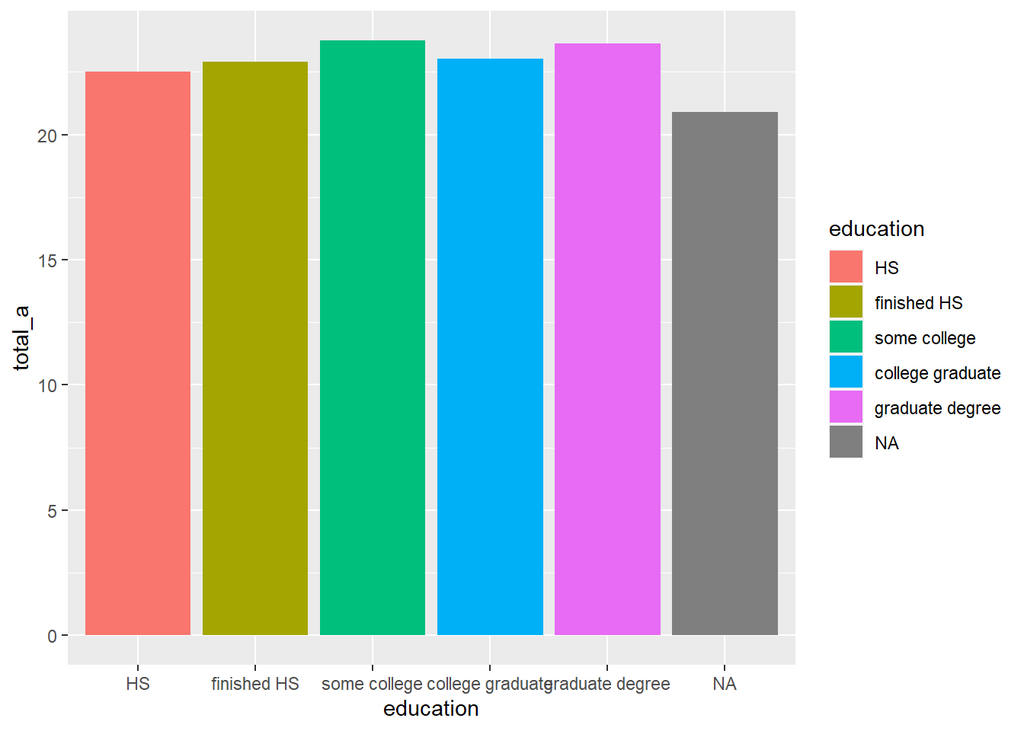

```r
mean_total_a <-
bfi_a |>
  group_by(education) |>
  summarise(total_a = mean(total_a, na.rm = TRUE))

ggplot(mean_total_a) +
  geom_col(aes(x = education, y = total_a, fill = education))
```

### 8.1.1 平均値の高い順に並び変え

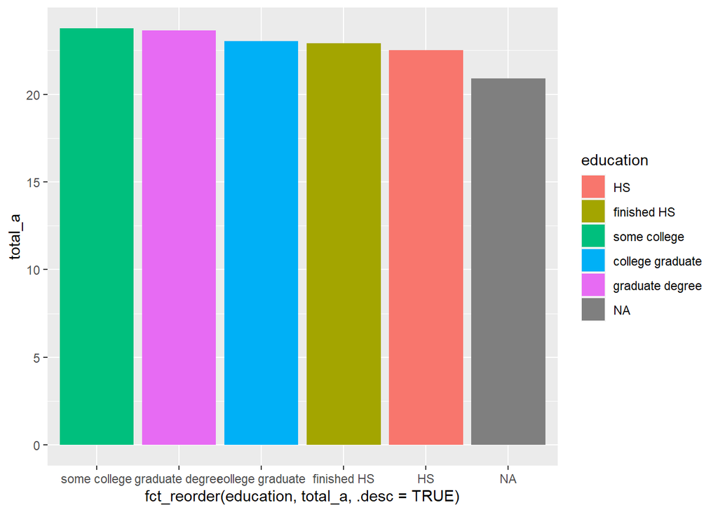

```r
ggplot(mean_total_a) +
  geom_col(aes(x = fct_reorder(education, total_a, .desc = TRUE),
               y = total_a, fill = education))
```

### 8.1.2 ラベル付与して見栄えを整える

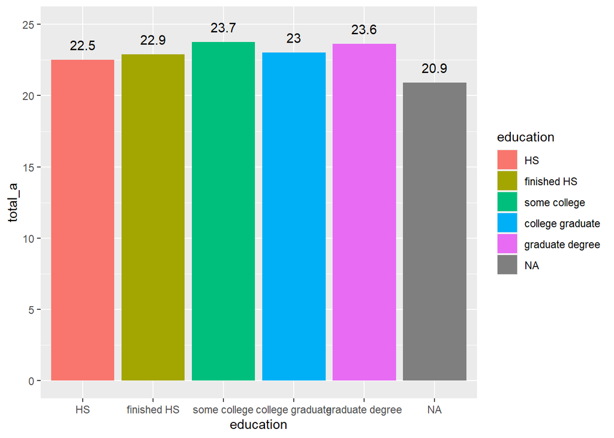

```r
ggplot(mean_total_a, aes(x = education, y = total_a, fill = education)) +
  geom_col() +
  geom_text(aes(label = round(total_a, 1)), vjust = -1) +
  scale_y_continuous(limits = c(0,25))
```

- `geom_text()`でラベル表示。`round()`で小数点第1位までにして，`vjust = -1`で棒グラフの上端から浮かせる設定に
- `scale_y_continuous()`で`limits =`により，y軸の表示範囲をラベルが全部表示できるように拡張

### 8.1.3 ラベル付与して見栄えを整える(2)

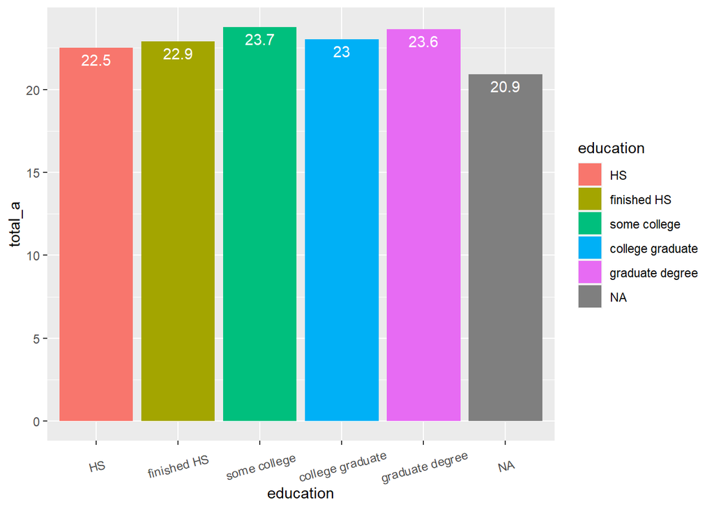

```r
ggplot(mean_total_a, aes(x = education, y = total_a, fill = education)) +
  geom_col() +
  geom_text(aes(label = round(total_a, 1)), vjust = 1.5,
            color = "white") +
  # scale_y_continuous(limits = c(0,25)) +
  theme(axis.text.x = element_text(angle = 15, vjust = 0.5))
```

### 8.1.4 グラフの色を変更

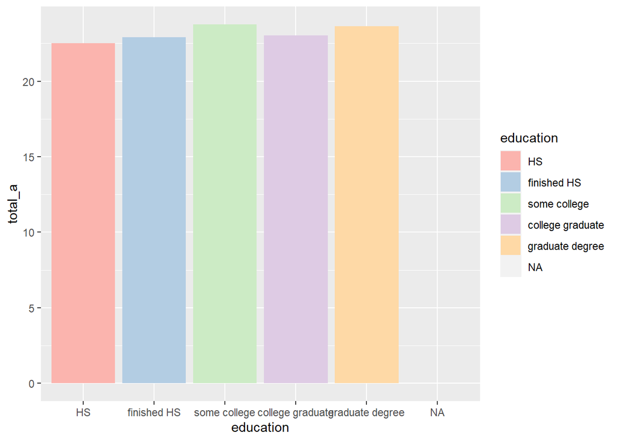

```r
ggplot(mean_total_a) +
  geom_col(aes(x = education, y = total_a, fill = education)) +
  scale_fill_brewer(palette = "Pastel1")
```

### 8.1.5 縦軸の数値の範囲変更

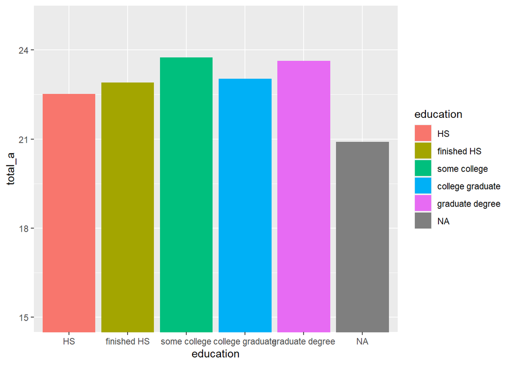

```r
ggplot(mean_total_a) +
  geom_col(aes(x = education, y = total_a, fill = education)) +
  scale_y_continuous(breaks = seq(15, 25, by = 3)) + # 横軸のラベル表示を15から25まで3ずつ
  coord_cartesian(ylim = c(15,25))                   # 横軸のデータ範囲表示を15から25までに限定
```

## 8.2 層別（2要因）の平均値の棒グラフ

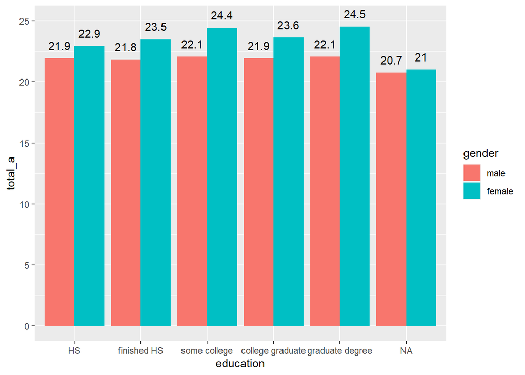

```r
mean_total_b <-
bfi_a |>
  group_by(gender,education) |>
  summarise(total_a = mean(total_a, na.rm = TRUE)) |>
  ungroup()

ggplot(mean_total_b, aes(x = education, y = total_a, fill = gender)) +
  geom_col(position = "dodge") +
  geom_text(aes(label = round(total_a, 1)), vjust = -1,
            position = position_dodge(width = 0.9)) +
  scale_y_continuous(limits = c(0,25))
```

- `fill =`2つ目の要因を指定しただけだと，棒グラフは重なったまま。`geom_col(position = "dodge")`で棒グラフを区分
- `geom_text()`に引数`position = position_dodge( )`を指定すると，ラベルも区分されたグラフごとに表示される。デフォルトだと重なってしまっている。

### 8.2.1 層別（2要因）の平均値の棒グラフ(femaleの値で昇順ソート)

- NAは対象外

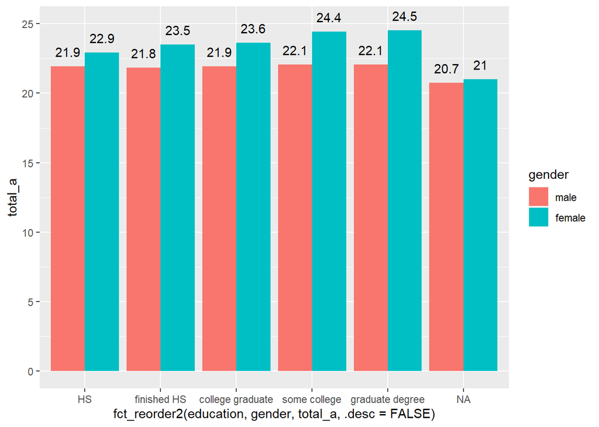

```r
ggplot(mean_total_b, aes(x = fct_reorder2(education, gender, total_a,                                         .desc = FALSE),
                         y = total_a, fill = gender)) +
  geom_col(position = "dodge") +
  geom_text(aes(label = round(total_a, 1)), vjust = -1,
            position = position_dodge(width = 0.9)) +
  scale_y_continuous(limits = c(0,25))
```

### 8.2.2 層別（2要因）の平均値の棒グラフ：基準線付き

- 線に被ってしまうラベルの位置調整

#### 8.2.2.1 被ったバージョン

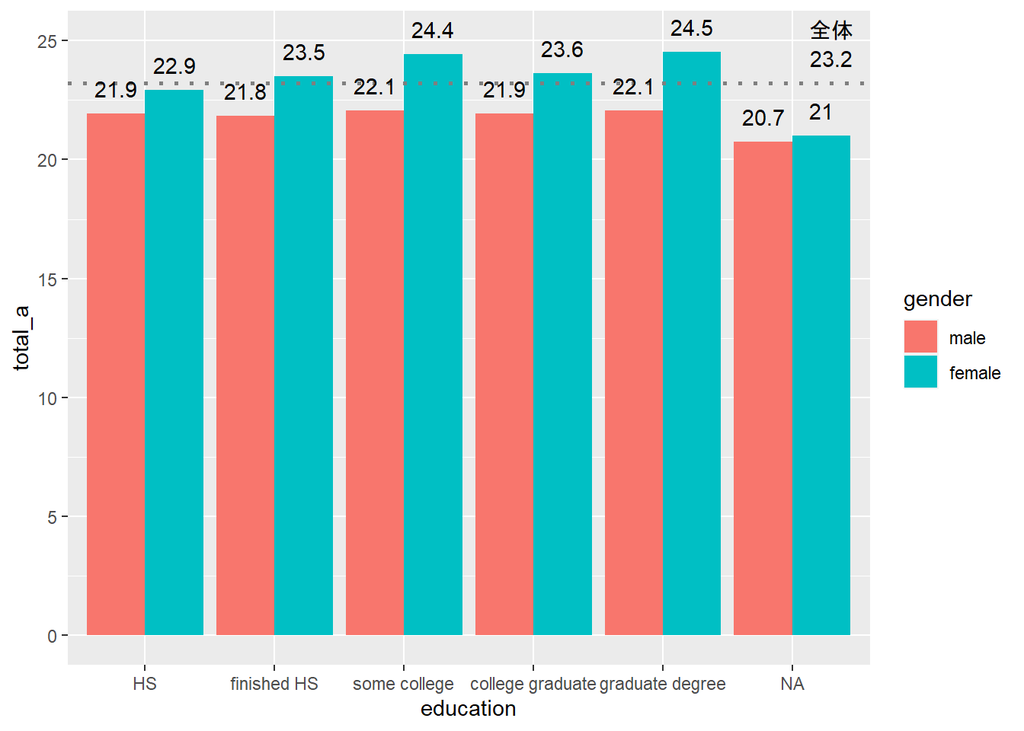

```r
mean_all <-
  bfi_a |>
  summarise(total_a = mean(total_a, na.rm = TRUE)) |>
  pull()

mean_total_b <-
bfi_a |>
  group_by(gender,education) |>
  summarise(total_a = mean(total_a, na.rm = TRUE))

ggplot(mean_total_b, aes(x = education, y = total_a, fill = gender)) +
  geom_col(position = "dodge") +
  geom_hline(yintercept = mean_all, linetype = "dotted",
             color = "gray50", size = 1) +
  geom_text(aes(label = round(total_a, 1)), vjust = -1,
            position = position_dodge(width = 0.9)) +
  annotate("text", x = 6.3, y = mean_all, vjust = -1,   # 全体平均値表示
           label = round(mean_all, 1)) +
  annotate("text", x = 6.3, y = mean_all + 1.2, vjust = -1,  # "全体"の文字表示
           label = "全体") +
  scale_y_continuous(limits = c(0,25))
```

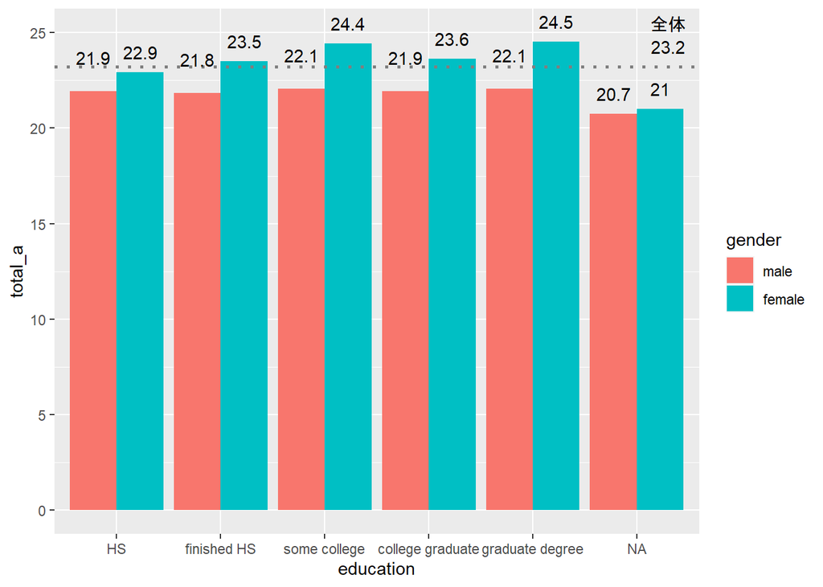

```r
ggplot(mean_total_b, aes(x = education, y = total_a, fill = gender)) +
  geom_col(position = "dodge") +
  geom_hline(yintercept = mean_all, linetype = "dotted",
             color = "gray50", size = 1) +
  geom_text(aes(label = round(total_a, 1),
                vjust = case_when(total_a <= (mean_all - 1) &     # 平均より-2点から-1点
                                  total_a >= (mean_all - 2) ~ -2, # 低かったら位置は-2
                                                       TRUE ~ -1) # その他の位置は-1
                ),
            position = position_dodge(width = 0.9)) +
  annotate("text", x = 6.3, y = mean_all, vjust = -1,
           label = round(mean_all, 1)) +
  annotate("text", x = 6.3, y = mean_all + 1.2, vjust = -1,
           label = "全体") +
  scale_y_continuous(limits = c(0,25))
```

## 8.4 ヒストグラム（カウント数ラベル付き）

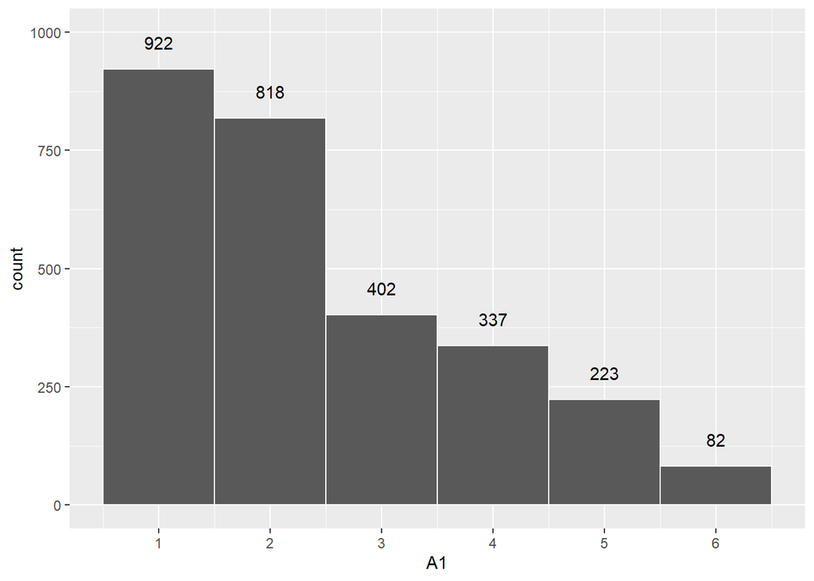

```r
ggplot(bfi, aes(A1)) +
  geom_histogram(bins = 6, color = "white") +      # binsは棒の数，colorは棒の線
  scale_x_continuous(breaks = seq(1, 6, by = 1)) + # 横軸の表示を1から6まで１ずつ
  stat_bin(bins = 6, geom="text", aes(label=..count..), vjust=-1.5) + # ラベル付与
  coord_cartesian(ylim = c(0,1000)) # デフォルトだとラベルが隠れてしまうので，縦軸広げる
```

- 縦軸表示の変更は`scale_y_continuous(limits = c(0, 1000))`でもいけた

## 8.5 facet_wrapで複数の図を一度に描くときに，複数ページに分割して表示する

- 大量に図を描くと1つ1つの図が小さくなって分かりにくい時があります。

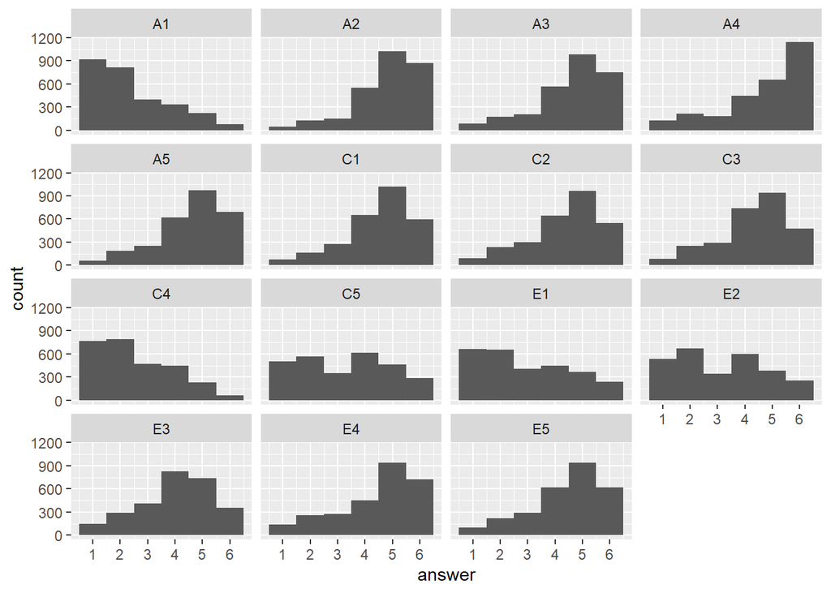

```r
bfi_long <-
bfi |>
  select(A1:E5, gender:age) |>
  gather(A1:E5, key = "items", value = "answer") |>
  as_tibble()

ggplot(bfi_long) +
  geom_histogram(aes(answer), bins = 6) + # binsはデフォルトが30なので水準数と同じに設定
  scale_x_continuous(breaks = seq(1,6, by = 1)) + # x軸の値をすべて表示 1から6まで1ごと
  facet_wrap( ~ items)
```

- ggforceパッケージを使えば分割して表示できます
  - ここでは1ページ目を表示

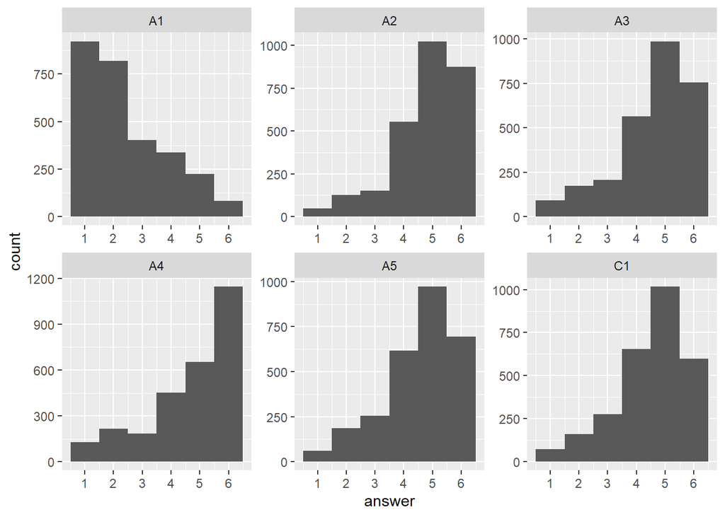

```r
library(ggforce)
ggplot(bfi_long) +
  geom_histogram(aes(answer), bins = 6) +
  scale_x_continuous(breaks = seq(1,6, by = 1)) +
  facet_wrap_paginate(~ items, nrow = 2, ncol = 3,  # ここに行と列の個数を指定
                      scales = "free", page = 1)    # 何ページ目を表示するか指定
```

- for loopを使って一度にすべて表示させます

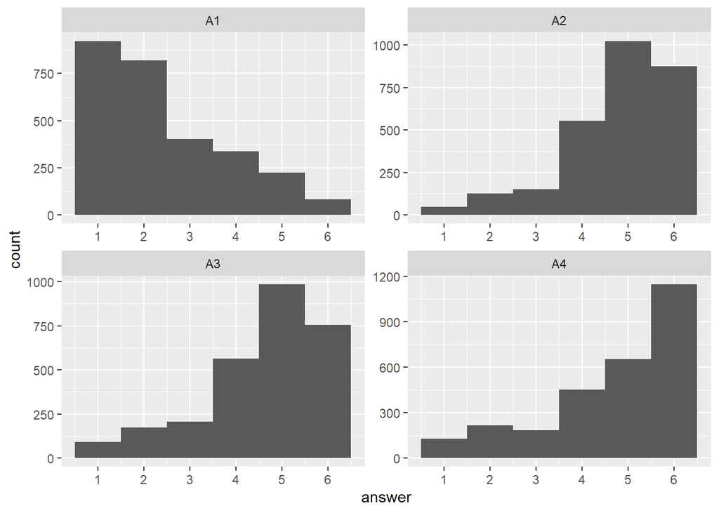

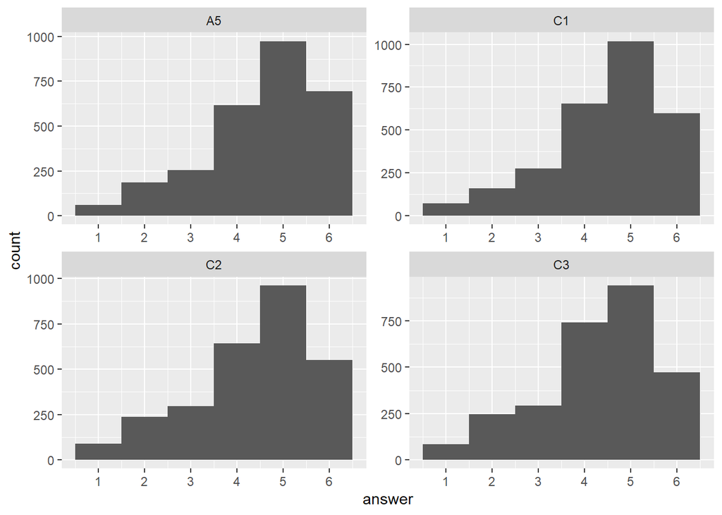

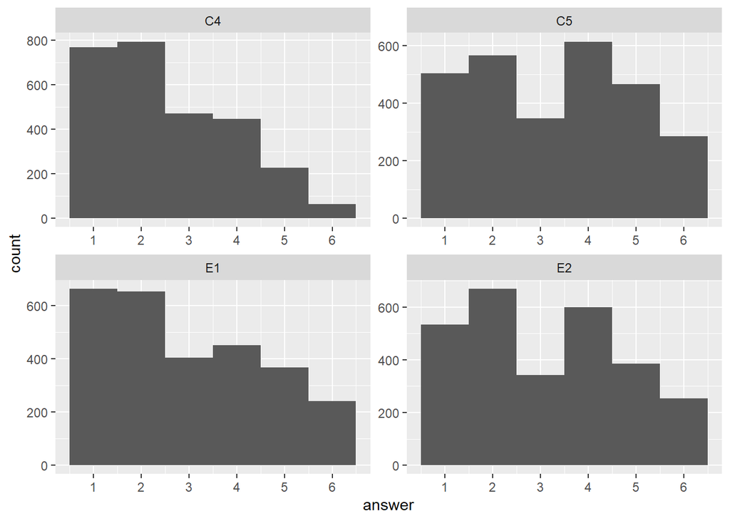

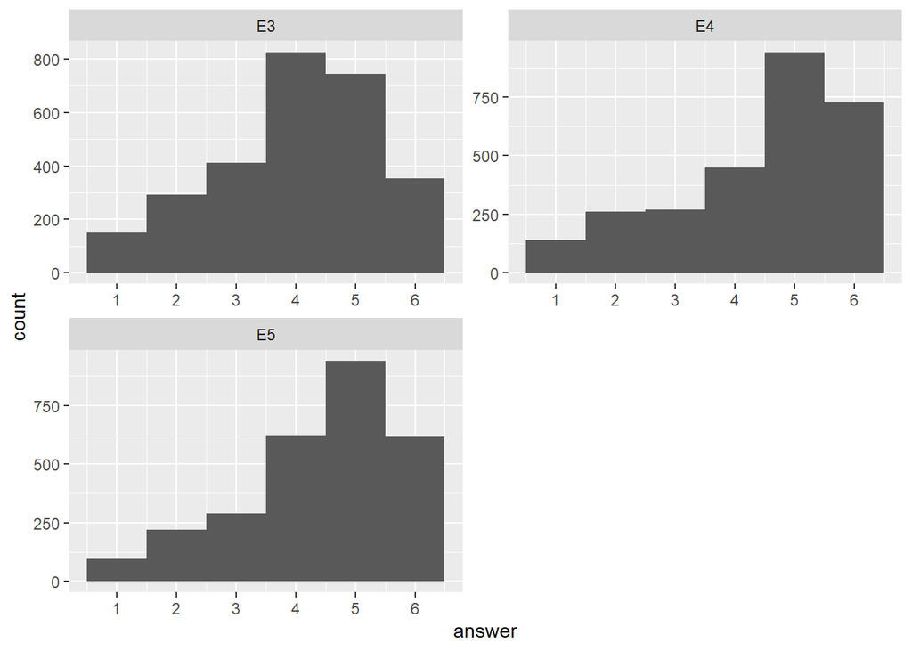

```r
for(i in 1:4){      # 作成されるページ数の範囲を指定
  print(
    ggplot(bfi_long) +
      geom_histogram(aes(answer), bins = 6) +
      scale_x_continuous(breaks = seq(1,6, by = 1)) +
      facet_wrap_paginate(~ items, nrow = 2, ncol = 2,
                          scales = "free", page = i)
  )
}
```

```r
# 自動で作成されるページ数を計算したい場合
# n_pages <- ceiling(
#   length(levels(bfi_long$items))/ 6)
```